# DATA-413/613

## 5.4 `summarise()`

- `summarise()`: Collapse many values down to a single summary

```r
summarise(flights, delay = mean(dep_delay, na.rm = TRUE))
```

```
## # A tibble: 1 × 1
##   delay
##   <dbl>
## 1  12.6
```

`summarise()` is not useful unless we pair it with `group_by()`.  
For example, if we applied exactly the same code to a data frame grouped by date, we get the average delay per date:

```r
by_day <- group_by(flights, year, month, day)
by_day
```

```
## # A tibble: 336,776 × 19
## # Groups:   year, month, day [365]
##     year month   day dep_time sched_dep_time dep_delay arr_time sched_arr_time
##    <int> <int> <int>    <int>          <int>     <dbl>    <int>          <int>
##  1  2013     1     1      517            515         2      830            819
##  2  2013     1     1      533            529         4      850            830
##  3  2013     1     1      542            540         2      923            850
##  4  2013     1     1      544            545        -1     1004           1022
##  5  2013     1     1      554            600        -6      812            837
##  6  2013     1     1      554            558        -4      740            728
##  7  2013     1     1      555            600        -5      913            854
##  8  2013     1     1      557            600        -3      709            723
##  9  2013     1     1      557            600        -3      838            846
## 10  2013     1     1      558            600        -2      753            745
## # ℹ 336,766 more rows
## # ℹ 11 more variables: arr_delay <dbl>, carrier <chr>, flight <int>,
## #   tailnum <chr>, origin <chr>, dest <chr>, air_time <dbl>, distance <dbl>,
## #   hour <dbl>, minute <dbl>, time_hour <dttm>
```

```r
summarise(by_day, delay = mean(dep_delay, na.rm = TRUE))
```

```
## # A tibble: 365 × 4
## # Groups:   year, month [12]
##     year month   day delay
##    <int> <int> <int> <dbl>
##  1  2013     1     1 11.5
##  2  2013     1     2 13.9
##  3  2013     1     3 11.0
##  4  2013     1     4  8.95
##  5  2013     1     5  5.73
##  6  2013     1     6  7.15
##  7  2013     1     7  5.42
##  8  2013     1     8  2.55
##  9  2013     1     9  2.28
## 10  2013     1    10  2.84
## # ℹ 355 more rows
```

Together `group_by()` and `summarise()` provide one of the tools that you’ll use most commonly when working with `dplyr`: grouped summaries.

```r
delays <- flights %>%
  group_by(dest) %>%
  summarise(
    count = n(),
    dist = mean(distance, na.rm = TRUE),
    delay = mean(arr_delay, na.rm = TRUE)
  ) %>%
  filter(count > 20, dest != "HNL")

delays
```

```
## # A tibble: 96 × 4
##    dest  count  dist delay
##    <chr> <int> <dbl> <dbl>
##  1 ABQ     254 1826   4.38
##  2 ACK     265  199   4.85
##  3 ALB     439  143  14.4
##  4 ATL   17215  757. 11.3
##  5 AUS    2439 1514.  6.02
##  6 AVL     275  584.  8.00
##  7 BDL     443  116   7.05
##  8 BGR     375  378   8.03
##  9 BHM     297  866. 16.9
## 10 BNA    6333  758. 11.8
## # ℹ 86 more rows
```

```r
delays %>%
  filter(dest == "ABQ")
```

```
## # A tibble: 1 × 4
##   dest  count  dist delay
##   <chr> <int> <dbl> <dbl>
## 1 ABQ     254  1826  4.38
```

You may have wondered about the `na.rm` argument we used above. What happens if we don’t set it?

```r
flights %>%
  group_by(year, month, day) %>%
  summarise(mean = mean(dep_delay))
```

```
## # A tibble: 365 × 4
## # Groups:   year, month [12]
##     year month   day  mean
##    <int> <int> <int> <dbl>
##  1  2013     1     1    NA
##  2  2013     1     2    NA
##  3  2013     1     3    NA
##  4  2013     1     4    NA
##  5  2013     1     5    NA
##  6  2013     1     6    NA
##  7  2013     1     7    NA
##  8  2013     1     8    NA
##  9  2013     1     9    NA
## 10  2013     1    10    NA
## # ℹ 355 more rows
```

if there’s any missing value in the input, the output will be a missing value. Fortunately, all aggregation functions have an na.rm argument which removes the missing values prior to computation:

```r
flights %>%
  group_by(year, month, day) %>%
  summarise(mean = mean(dep_delay, na.rm = TRUE))
```

```
## # A tibble: 365 × 4
## # Groups:   year, month [12]
##     year month   day  mean
##    <int> <int> <int> <dbl>
##  1  2013     1     1 11.5
##  2  2013     1     2 13.9
##  3  2013     1     3 11.0
##  4  2013     1     4  8.95
##  5  2013     1     5  5.73
##  6  2013     1     6  7.15
##  7  2013     1     7  5.42
##  8  2013     1     8  2.55
##  9  2013     1     9  2.28
## 10  2013     1    10  2.84
## # ℹ 355 more rows
```

In this case, where missing values represent cancelled flights, we could also tackle the problem by first removing the cancelled flights.

```r
not_cancelled <- flights %>%
  filter(!is.na(dep_delay), !is.na(arr_delay))

not_cancelled %>%
  group_by(year, month, day) %>%
  summarise(mean = mean(dep_delay))
```

```
## # A tibble: 365 × 4
## # Groups:   year, month [12]
##     year month   day  mean
##    <int> <int> <int> <dbl>
##  1  2013     1     1 11.4
##  2  2013     1     2 13.7
##  3  2013     1     3 10.9
##  4  2013     1     4  8.97
##  5  2013     1     5  5.73
##  6  2013     1     6  7.15
##  7  2013     1     7  5.42
##  8  2013     1     8  2.56
##  9  2013     1     9  2.30
## 10  2013     1    10  2.84
## # ℹ 355 more rows
```

### 5.4.1 COUNTS

**Aggregate functions** in R splits the data into subsets, computes summary statistics for each subsets and returns the result in a group by form.

Whenever you do any aggregation, it’s always a good idea to include either a count (n()), or a count of non-missing values (sum(!is.na(x))). That way you can check that you’re not drawing conclusions based on very small amounts of data. For example, let’s look at the planes (identified by their tail number) that have the highest average delays:

```r
delays <- not_cancelled %>%
  group_by(tailnum) %>%
  summarise(
    delay = mean(arr_delay)
  )

delays
```

```
## # A tibble: 4,037 × 2
##    tailnum  delay
##    <chr>    <dbl>
##  1 D942DN  31.5
##  2 N0EGMQ   9.98
##  3 N10156  12.7
##  4 N102UW   2.94
##  5 N103US  -6.93
##  6 N104UW   1.80
##  7 N10575  20.7
##  8 N105UW  -0.267
##  9 N107US  -5.73
## 10 N108UW  -1.25
## # ℹ 4,027 more rows
```

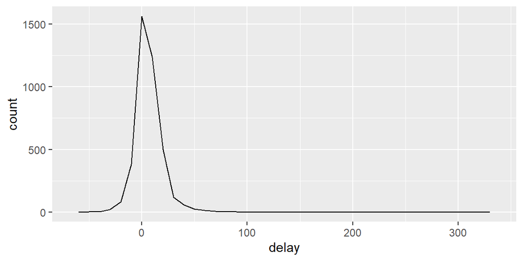

```r
ggplot(data = delays, mapping = aes(x = delay)) +
  geom_freqpoly(binwidth = 10)
```

there are some planes that have an average delay of 5 hours (300 minutes)!  
We can get more insight if we draw a scatterplot of number of flights vs. average delay:

```r
delays <- not_cancelled %>%
  group_by(tailnum) %>%
  summarise(
    delay = mean(arr_delay, na.rm = TRUE),
    n = n()
  )
delays
```

```
## # A tibble: 4,037 × 3
##    tailnum  delay     n
##    <chr>    <dbl> <int>
##  1 D942DN  31.5       4
##  2 N0EGMQ   9.98    352
##  3 N10156  12.7     145
##  4 N102UW   2.94     48
##  5 N103US  -6.93     46
##  6 N104UW   1.80     46
##  7 N10575  20.7     269
##  8 N105UW  -0.267    45
##  9 N107US  -5.73     41
## 10 N108UW  -1.25     60
## # ℹ 4,027 more rows
```

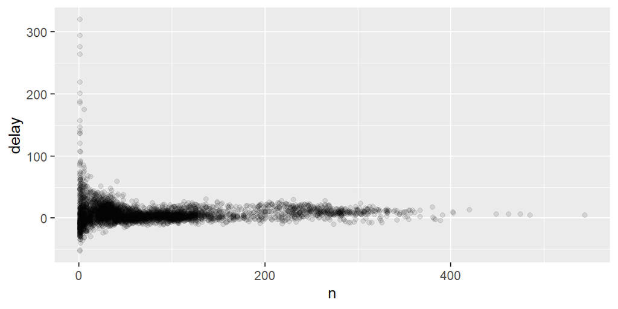

```r
ggplot(data = delays, mapping = aes(x = n, y = delay)) +
  geom_point(alpha = 1/10)
```

Not surprisingly, there is much greater variation in the average delay when there are few flights. The shape of this plot is very characteristic: whenever you plot a mean (or other summary) vs. group size, you’ll see that the variation decreases as the sample size increases.

### 5.4.2 Usefule functions

Just using means, counts, and sum can get you a long way, but R provides many other useful summary functions:

1. Measures of location: we’ve used `mean(x)`, but `median(x)` is also useful.

```r
not_cancelled %>%
  group_by(year, month, day) %>%
  summarise(
    avg_delay1 = mean(arr_delay),
    avg_delay2 = mean(arr_delay[arr_delay > 0]) # the average positive delay
  )
```

```
## # A tibble: 365 × 5
## # Groups:   year, month [12]
##     year month   day avg_delay1 avg_delay2
##    <int> <int> <int>      <dbl>      <dbl>
##  1  2013     1     1     12.7         32.5
##  2  2013     1     2     12.7         32.0
##  3  2013     1     3      5.73        27.7
##  4  2013     1     4     -1.93        28.3
##  5  2013     1     5     -1.53        22.6
##  6  2013     1     6      4.24        24.4
##  7  2013     1     7     -4.95        27.8
##  8  2013     1     8     -3.23        20.8
##  9  2013     1     9     -0.264       25.6
## 10  2013     1    10     -5.90        27.3
## # ℹ 355 more rows
```

2. Measures of spread: `sd(x)`, `IQR(x)`, `mad(x)`. The root mean squared deviation, or standard deviation `sd(x)`, is the standard measure of spread. The interquartile range `IQR(x)` and median absolute deviation `mad(x)` are robust equivalents that may be more useful if you have outliers.

```r
# Why is distance to some destinations more variable than to others?
not_cancelled %>%
  group_by(dest) %>%
  summarise(distance_sd = sd(distance)) %>%
  arrange(desc(distance_sd))
```

```
## # A tibble: 104 × 2
##    dest  distance_sd
##    <chr>       <dbl>
##  1 EGE         10.5
##  2 SAN         10.4
##  3 SFO         10.2
##  4 HNL         10.0
##  5 SEA          9.98
##  6 LAS          9.91
##  7 PDX          9.87
##  8 PHX          9.86
##  9 LAX          9.66
## 10 IND          9.46
## # ℹ 94 more rows
```

3. Measures of rank: `min(x)`, `quantile(x, 0.25)`, `max(x)`. Quantiles are a generalisation of the median. For example, `quantile(x, 0.25)` will find a value of x that is greater than 25% of the values, and less than the remaining 75%.

```r
x <- c(1, 2, 12 ,22, 25, 35, 40 )  # 25%--> (2 +12)/2 -- 2, 50% --22, -- 75%--> (25 +35)/2
x
```

```
## [1]  1  2 12 22 25 35 40
```

```r
quantile(x, 0.25)
```

```
## 25%
##   7
```

```r
quantile(x)
```

```
##   0%  25%  50%  75% 100%
##    1    7   22   30   40
```

```r
# When do the first and last flights leave each day?
not_cancelled %>%
  group_by(year, month, day) %>%
  summarise(
    first = min(dep_time),
    last = max(dep_time)
  )
```

```
## # A tibble: 365 × 5
## # Groups:   year, month [12]
##     year month   day first  last
##    <int> <int> <int> <int> <int>
##  1  2013     1     1   517  2356
##  2  2013     1     2    42  2354
##  3  2013     1     3    32  2349
##  4  2013     1     4    25  2358
##  5  2013     1     5    14  2357
##  6  2013     1     6    16  2355
##  7  2013     1     7    49  2359
##  8  2013     1     8   454  2351
##  9  2013     1     9     2  2252
## 10  2013     1    10     3  2320
## # ℹ 355 more rows
```

4. Measures of position: `first(x)`, `nth(x, 2)`, `last(x)`. These work similarly to `x[1]`, `x[2]`, and `x[length(x)]` but let you set a default value if that position does not exist (i.e. you’re trying to get the 3rd element from a group that only has two elements). For example, we can find the first and last departure for each day:

```r
not_cancelled %>%
  group_by(year, month, day) %>%
  summarise(
    first_dep = first(dep_time),
    last_dep = last(dep_time)
  )
```

```
## # A tibble: 365 × 5
## # Groups:   year, month [12]
##     year month   day first_dep last_dep
##    <int> <int> <int>     <int>    <int>
##  1  2013     1     1       517     2356
##  2  2013     1     2        42     2354
##  3  2013     1     3        32     2349
##  4  2013     1     4        25     2358
##  5  2013     1     5        14     2357
##  6  2013     1     6        16     2355
##  7  2013     1     7        49     2359
##  8  2013     1     8       454     2351
##  9  2013     1     9         2     2252
## 10  2013     1    10         3     2320
## # ℹ 355 more rows
```

These functions are complementary to filtering on ranks. Filtering gives you all variables, with each observation in a separate row:

```r
not_cancelled %>%
  group_by(year, month, day) %>%
  mutate(r = min_rank(desc(dep_time))) %>%
  filter(r %in% range(r))
```

```
## # A tibble: 770 × 20
## # Groups:   year, month, day [365]
##     year month   day dep_time sched_dep_time dep_delay arr_time sched_arr_time
##    <int> <int> <int>    <int>          <int>     <dbl>    <int>          <int>
##  1  2013     1     1      517            515         2      830            819
##  2  2013     1     1     2356           2359        -3      425            437
##  3  2013     1     2       42           2359        43      518            442
##  4  2013     1     2     2354           2359        -5      413            437
##  5  2013     1     3       32           2359        33      504            442
##  6  2013     1     3     2349           2359       -10      434            445
##  7  2013     1     4       25           2359        26      505            442
##  8  2013     1     4     2358           2359        -1      429            437
##  9  2013     1     4     2358           2359        -1      436            445
## 10  2013     1     5       14           2359        15      503            445
## # ℹ 760 more rows
## # ℹ 12 more variables: arr_delay <dbl>, carrier <chr>, flight <int>,
## #   tailnum <chr>, origin <chr>, dest <chr>, air_time <dbl>, distance <dbl>,
## #   hour <dbl>, minute <dbl>, time_hour <dttm>, r <int>
```

5. Counts: You’ve seen `n()`, which takes no arguments, and returns the size of the current group. To count the number of non-missing values, use `sum(!is.na(x))`. To count the number of distinct (unique) values, use `n_distinct(x)`.

```r
# Which destinations have the most carriers?
not_cancelled %>%
  group_by(dest) %>%
  summarise(carriers = n_distinct(carrier)) %>%
  arrange(desc(carriers))
```

```
## # A tibble: 104 × 2
##    dest  carriers
##    <chr>    <int>
##  1 ATL          7
##  2 BOS          7
##  3 CLT          7
##  4 ORD          7
##  5 TPA          7
##  6 AUS          6
##  7 DCA          6
##  8 DTW          6
##  9 IAD          6
## 10 MSP          6
## # ℹ 94 more rows
```

Counts are so useful that `dplyr` provides a simple helper if all you want is a count:

```r
not_cancelled %>%
  count(dest)
```

```
## # A tibble: 104 × 2
##    dest      n
##    <chr> <int>
##  1 ABQ     254
##  2 ACK     264
##  3 ALB     418
##  4 ANC       8
##  5 ATL   16837
##  6 AUS    2411
##  7 AVL     261
##  8 BDL     412
##  9 BGR     358
## 10 BHM     269
## # ℹ 94 more rows
```

You can optionally provide a weight variable. For example, you could use this to “count” (sum) the total number of miles a plane flew:

```r
not_cancelled %>%
  count(tailnum, wt = distance)
```

```
## # A tibble: 4,037 × 2
##    tailnum      n
##    <chr>    <dbl>
##  1 D942DN    3418
##  2 N0EGMQ  239143
##  3 N10156  109664
##  4 N102UW   25722
##  5 N103US   24619
##  6 N104UW   24616
##  7 N10575  139903
##  8 N105UW   23618
##  9 N107US   21677
## 10 N108UW   32070
## # ℹ 4,027 more rows
```

6. Counts and proportions of logical values: `sum(x > 10)`, `mean(y == 0)`. When used with numeric functions, TRUE is converted to 1 and FALSE to 0. This makes `sum()` and `mean()` very useful: `sum(x)` gives the number of TRUEs in x, and `mean(x)` gives the proportion.

```r
# How many flights left before 5am? (these usually indicate delayed
# flights from the previous day)
not_cancelled %>%
  group_by(year, month, day) %>%
  summarise(n_early = sum(dep_time < 500))
```

```
## # A tibble: 365 × 4
## # Groups:   year, month [12]
##     year month   day n_early
##    <int> <int> <int>   <int>
##  1  2013     1     1       0
##  2  2013     1     2       3
##  3  2013     1     3       4
##  4  2013     1     4       3
##  5  2013     1     5       3
##  6  2013     1     6       2
##  7  2013     1     7       2
##  8  2013     1     8       1
##  9  2013     1     9       3
## 10  2013     1    10       3
## # ℹ 355 more rows
```

```r
# What proportion of flights are delayed by more than an hour?
not_cancelled %>%
  group_by(year, month, day) %>%
  summarise(hour_prop = mean(arr_delay > 60))
```

```
## # A tibble: 365 × 4
## # Groups:   year, month [12]
##     year month   day hour_prop
##    <int> <int> <int>     <dbl>
##  1  2013     1     1    0.0722
##  2  2013     1     2    0.0851
##  3  2013     1     3    0.0567
##  4  2013     1     4    0.0396
##  5  2013     1     5    0.0349
##  6  2013     1     6    0.0470
##  7  2013     1     7    0.0333
##  8  2013     1     8    0.0213
##  9  2013     1     9    0.0202
## 10  2013     1    10    0.0183
## # ℹ 355 more rows
```

### 5.4.3 Grouping by multiple variables

When you group by multiple variables, each summary peels off one level of the grouping. That makes it easy to progressively roll up a dataset:

```r
daily <- group_by(flights, year, month, day)
(per_day   <- summarise(daily, flights = n()))
```

```
## # A tibble: 365 × 4
## # Groups:   year, month [12]
##     year month   day flights
##    <int> <int> <int>   <int>
##  1  2013     1     1     842
##  2  2013     1     2     943
##  3  2013     1     3     914
##  4  2013     1     4     915
##  5  2013     1     5     720
##  6  2013     1     6     832
##  7  2013     1     7     933
##  8  2013     1     8     899
##  9  2013     1     9     902
## 10  2013     1    10     932
## # ℹ 355 more rows
```

```r
(per_month <- summarise(per_day, flights = sum(flights)))
```

```
## # A tibble: 12 × 3
## # Groups:   year [1]
##     year month flights
##    <int> <int>   <int>
##  1  2013     1   27004
##  2  2013     2   24951
##  3  2013     3   28834
##  4  2013     4   28330
##  5  2013     5   28796
##  6  2013     6   28243
##  7  2013     7   29425
##  8  2013     8   29327
##  9  2013     9   27574
## 10  2013    10   28889
## 11  2013    11   27268
## 12  2013    12   28135
```

```r
(per_year  <- summarise(per_month, flights = sum(flights)))
```

```
## # A tibble: 1 × 2
##    year flights
##   <int>   <int>
## 1  2013  336776
```

### 5.4.4 Ungrouping

If you need to remove grouping, and return to operations on ungrouped data, use ungroup().

```r
daily %>%
  ungroup() %>%             # no longer grouped by date
  summarise(flights = n())  # all flights
```

```
## # A tibble: 1 × 1
##   flights
##     <int>
## 1  336776
```

```r
# What heppen we don't ungroup?
daily %>%
  summarise(flights = n())  # all flights
```

```
## # A tibble: 365 × 4
## # Groups:   year, month [12]
##     year month   day flights
##    <int> <int> <int>   <int>
##  1  2013     1     1     842
##  2  2013     1     2     943
##  3  2013     1     3     914
##  4  2013     1     4     915
##  5  2013     1     5     720
##  6  2013     1     6     832
##  7  2013     1     7     933
##  8  2013     1     8     899
##  9  2013     1     9     902
## 10  2013     1    10     932
## # ℹ 355 more rows
```

### 5.4.5 Grouped mutates (and filters)

Grouping is most useful in conjunction with `summarise()`, but you can also do convenient operations with `mutate()` and `filter()`:

- Find the worst members of each group:

```r
flights_sml %>%
  group_by(year, month, day) %>%
  filter(rank(desc(arr_delay)) < 10)
```

```
## # A tibble: 3,306 × 7
## # Groups:   year, month, day [365]
##     year month   day dep_delay arr_delay distance air_time
##    <int> <int> <int>     <dbl>     <dbl>    <dbl>    <dbl>
##  1  2013     1     1       853       851      184       41
##  2  2013     1     1       290       338     1134      213
##  3  2013     1     1       260       263      266       46
##  4  2013     1     1       157       174      213       60
##  5  2013     1     1       216       222      708      121
##  6  2013     1     1       255       250      589      115
##  7  2013     1     1       285       246     1085      146
##  8  2013     1     1       192       191      199       44
##  9  2013     1     1       379       456     1092      222
## 10  2013     1     2       224       207      550       94
## # ℹ 3,296 more rows
```

- Find all groups bigger than a threshold:

```r
popular_dests <- flights %>%
  group_by(dest) %>%
  filter(n() > 365)
popular_dests
```

```
## # A tibble: 332,577 × 19
## # Groups:   dest [77]
##     year month   day dep_time sched_dep_time dep_delay arr_time sched_arr_time
##    <int> <int> <int>    <int>          <int>     <dbl>    <int>          <int>
##  1  2013     1     1      517            515         2      830            819
##  2  2013     1     1      533            529         4      850            830
##  3  2013     1     1      542            540         2      923            850
##  4  2013     1     1      544            545        -1     1004           1022
##  5  2013     1     1      554            600        -6      812            837
##  6  2013     1     1      554            558        -4      740            728
##  7  2013     1     1      555            600        -5      913            854
##  8  2013     1     1      557            600        -3      709            723
##  9  2013     1     1      557            600        -3      838            846
## 10  2013     1     1      558            600        -2      753            745
## # ℹ 332,567 more rows
## # ℹ 11 more variables: arr_delay <dbl>, carrier <chr>, flight <int>,
## #   tailnum <chr>, origin <chr>, dest <chr>, air_time <dbl>, distance <dbl>,
## #   hour <dbl>, minute <dbl>, time_hour <dttm>
```

- Standardise to compute per group metrics:

```r
popular_dests %>%
  filter(arr_delay > 0) %>%
  mutate(prop_delay = arr_delay / sum(arr_delay)) %>%
  select(year:day, dest, arr_delay, prop_delay)
```

```
## # A tibble: 131,106 × 6
## # Groups:   dest [77]
##     year month   day dest  arr_delay prop_delay
##    <int> <int> <int> <chr>     <dbl>      <dbl>
##  1  2013     1     1 IAH          11  0.000111
##  2  2013     1     1 IAH          20  0.000201
##  3  2013     1     1 MIA          33  0.000235
##  4  2013     1     1 ORD          12  0.0000424
##  5  2013     1     1 FLL          19  0.0000938
##  6  2013     1     1 ORD           8  0.0000283
##  7  2013     1     1 LAX           7  0.0000344
##  8  2013     1     1 DFW          31  0.000282
##  9  2013     1     1 ATL          12  0.0000400
## 10  2013     1     1 DTW          16  0.000116
## # ℹ 131,096 more rows
```

A grouped filter is a grouped mutate followed by an ungrouped filter. I generally avoid them except for quick and dirty manipulations: otherwise it’s hard to check that you’ve done the manipulation correctly.

Functions that work most naturally in grouped mutates and filters are known as window functions (vs. the summary functions used for summaries). You can learn more about useful window functions in the corresponding vignette: `vignette("window-functions")`.

-A **vignette** is a long-form guide to your package. Function documentation is great if you know the name of the function you need, but it’s useless otherwise. A vignette is like a book chapter or an academic paper: it can describe the problem that your package is designed to solve, and then show the reader how to solve it.

# 6 Recoding

```r
estate <- read_csv(file = "https://dcgerard.github.io/stat_412_612/data/estate.csv")
```

- `recode()`:
  - Takes a vector as its ﬁrst argument.
  - Each subsequent argument contains two values separated by an equals sign.
  - The value on the left of the equals sign is the current value inside the vector.
  - The value on the right of the equals sign is the new value for the vector.
  - If the current value inside the vector is a numeric, then you need to surround its value by backticks.
  - It returns a vector with replaced values.
- estate contains the following variables:
  - `Price`: Sales price of residence (in dollars)
  - `Area`: Finished area of residence (in square feet)
  - `Bed`: Total number of bedrooms in residence
  - `Bath`: Total number of bathrooms in residence
  - `AC`: 1 = presence of air conditioning, 0 = absence of air conditioning
  - `Garage`: Number of cars that a garage will hold
  - `Pool`: 1 = presence of a pool, 0 = absence of a pool
  - `Year`: Year property was originally constructed
  - `Quality`: Index for quality of construction. High, Medium, or Low.
  - `Style`: Categorical variable indicating architectural style
  - `Lot`: Lot size (in square feet)
  - Highway`: 1 = highway adjacent, 0 = highway not adjacent.\
- It would be better if we could change the 0/1 coding for AC, Pool, and Highway to something more informative. That way we won’t have to always look up the coding during our analysis.\
- Let’s use `recode()` in to change the Quality values in the estate data frame.

**Recall: we need to use `mutate()` to modify a variable in a data frame.** **Note: `estate` is a dataframe not a vector.**

```r
estate %>%
  recode(Quality,
         High = "Palace",
         Medium = "Home",
         Low = "Slum") ->
  estate_n
```

```
## Error in UseMethod("recode"): no applicable method for 'recode' applied to an object of class "c('spec_tbl_df', 'tbl_df', 'tbl', 'data.frame')"
```

```r
glimpse(estate_n)
```

```
## Error in eval(expr, envir, enclos): object 'estate_n' not found
```

```r
estate %>%
  mutate(Quality = recode(Quality,
                          High = "Palace",
                          Medium = "Home",
                          Low = "Slum")) ->
  estate_1
glimpse(estate_1)
```

```
## Rows: 522
## Columns: 12
## $ Price   <dbl> 360000, 340000, 250000, 205500, 275500, 248000, 229900, 150000…
## $ Area    <dbl> 3032, 2058, 1780, 1638, 2196, 1966, 2216, 1597, 1622, 1976, 28…
## $ Bed     <dbl> 4, 4, 4, 4, 4, 4, 3, 2, 3, 3, 7, 3, 5, 5, 3, 5, 2, 3, 4, 3, 4,…
## $ Bath    <dbl> 4, 2, 3, 2, 3, 3, 2, 1, 2, 3, 5, 4, 4, 4, 3, 5, 2, 4, 3, 3, 3,…
## $ AC      <dbl> 1, 1, 1, 1, 1, 1, 1, 1, 1, 0, 0, 1, 1, 1, 1, 1, 1, 1, 1, 1, 1,…
## $ Garage  <dbl> 2, 2, 2, 2, 2, 5, 2, 1, 2, 1, 2, 3, 3, 2, 2, 2, 2, 2, 2, 2, 2,…
## $ Pool    <dbl> 0, 0, 0, 0, 0, 1, 0, 0, 0, 0, 1, 0, 0, 0, 0, 0, 0, 0, 0, 0, 0,…
## $ Year    <dbl> 1972, 1976, 1980, 1963, 1968, 1972, 1972, 1955, 1975, 1918, 19…
## $ Quality <chr> "Home", "Home", "Home", "Home", "Home", "Home", "Home", "Home"…
## $ Style   <dbl> 1, 1, 1, 1, 7, 1, 7, 1, 1, 1, 7, 1, 7, 5, 1, 6, 1, 7, 7, 1, 2,…
## $ Lot     <dbl> 22221, 22912, 21345, 17342, 21786, 18902, 18639, 22112, 14321,…
## $ Highway <dbl> 0, 0, 0, 0, 0, 0, 0, 0, 0, 0, 0, 0, 0, 0, 0, 0, 0, 0, 0, 0, 0,…
```

```r
unique(estate_2$AC)
```

[output not shown]

```
## [1] "AC"    "No.AC"
```

- **Recode with Logicals** with `if_else()`
- Sometimes, it is easier to recode based on logical statements.
- For example, suppose we want to recode the “Bath” variable to have values 1, 2, 3, and >3. One way to do this would be:

```r
unique(estate$Bath)
```

```
## [1] 4 2 3 1 5 6 0 7
```

```r
estate %>%
  mutate( Bath = recode(Bath,
                       `4` = ">3",
                       `5` = ">3",
                       `6` = ">3",
                       `7` = ">3")) ->
  estate_tem
glimpse(estate_tem)
```

```
## Rows: 522
## Columns: 12
## $ Price   <dbl> 360000, 340000, 250000, 205500, 275500, 248000, 229900, 150000…
## $ Area    <dbl> 3032, 2058, 1780, 1638, 2196, 1966, 2216, 1597, 1622, 1976, 28…
## $ Bed     <dbl> 4, 4, 4, 4, 4, 4, 3, 2, 3, 3, 7, 3, 5, 5, 3, 5, 2, 3, 4, 3, 4,…
## $ Bath    <chr> ">3", NA, NA, NA, NA, NA, NA, NA, NA, NA, ">3", ">3", ">3", ">…
## $ AC      <dbl> 1, 1, 1, 1, 1, 1, 1, 1, 1, 0, 0, 1, 1, 1, 1, 1, 1, 1, 1, 1, 1,…
## $ Garage  <dbl> 2, 2, 2, 2, 2, 5, 2, 1, 2, 1, 2, 3, 3, 2, 2, 2, 2, 2, 2, 2, 2,…
## $ Pool    <dbl> 0, 0, 0, 0, 0, 1, 0, 0, 0, 0, 1, 0, 0, 0, 0, 0, 0, 0, 0, 0, 0,…
## $ Year    <dbl> 1972, 1976, 1980, 1963, 1968, 1972, 1972, 1955, 1975, 1918, 19…
## $ Quality <chr> "Medium", "Medium", "Medium", "Medium", "Medium", "Medium", "M…
## $ Style   <dbl> 1, 1, 1, 1, 7, 1, 7, 1, 1, 1, 7, 1, 7, 5, 1, 6, 1, 7, 7, 1, 2,…
## $ Lot     <dbl> 22221, 22912, 21345, 17342, 21786, 18902, 18639, 22112, 14321,…
## $ Highway <dbl> 0, 0, 0, 0, 0, 0, 0, 0, 0, 0, 0, 0, 0, 0, 0, 0, 0, 0, 0, 0, 0,…
```

```r
unique(estate_tem$Bath)
```

```
## [1] ">3" NA
```

We should make the value of `Bath` as chareacter. Why? because of the `>3`.

```r
estate %>%
  mutate( Bath = as.character(Bath),
          Bath = recode(Bath,
                       `4` = ">3",
                       `5` = ">3",
                       `6` = ">3",
                       `7` = ">3")) ->
  estate_temp
glimpse(estate_temp)
```

```
## Rows: 522
## Columns: 12
## $ Price   <dbl> 360000, 340000, 250000, 205500, 275500, 248000, 229900, 150000…
## $ Area    <dbl> 3032, 2058, 1780, 1638, 2196, 1966, 2216, 1597, 1622, 1976, 28…
## $ Bed     <dbl> 4, 4, 4, 4, 4, 4, 3, 2, 3, 3, 7, 3, 5, 5, 3, 5, 2, 3, 4, 3, 4,…
## $ Bath    <chr> ">3", "2", "3", "2", "3", "3", "2", "1", "2", "3", ">3", ">3",…
## $ AC      <dbl> 1, 1, 1, 1, 1, 1, 1, 1, 1, 0, 0, 1, 1, 1, 1, 1, 1, 1, 1, 1, 1,…
## $ Garage  <dbl> 2, 2, 2, 2, 2, 5, 2, 1, 2, 1, 2, 3, 3, 2, 2, 2, 2, 2, 2, 2, 2,…
## $ Pool    <dbl> 0, 0, 0, 0, 0, 1, 0, 0, 0, 0, 1, 0, 0, 0, 0, 0, 0, 0, 0, 0, 0,…
## $ Year    <dbl> 1972, 1976, 1980, 1963, 1968, 1972, 1972, 1955, 1975, 1918, 19…
## $ Quality <chr> "Medium", "Medium", "Medium", "Medium", "Medium", "Medium", "M…
## $ Style   <dbl> 1, 1, 1, 1, 7, 1, 7, 1, 1, 1, 7, 1, 7, 5, 1, 6, 1, 7, 7, 1, 2,…
## $ Lot     <dbl> 22221, 22912, 21345, 17342, 21786, 18902, 18639, 22112, 14321,…
## $ Highway <dbl> 0, 0, 0, 0, 0, 0, 0, 0, 0, 0, 0, 0, 0, 0, 0, 0, 0, 0, 0, 0, 0,…
```

```r
unique(estate_temp$Bath)
```

```
## [1] ">3" "2"  "3"  "1"  "0"
```

- But this is a lot of typing. But we know how to obtain`TRUE`’s and `FALSE`’s based on whether a house has more than 3 bathrooms.

To use logical estatement, we want to get `TRUE`’s or `FALSE`’s. How can we do that? We are looking for the houses that have more than 3 Bathrooms. Thus `Bath > 3`.

```r
estate %>%
  mutate(Bath > 3) %>%

glimpse()
```

```
## Rows: 522
## Columns: 13
## $ Price      <dbl> 360000, 340000, 250000, 205500, 275500, 248000, 229900, 150…
## $ Area       <dbl> 3032, 2058, 1780, 1638, 2196, 1966, 2216, 1597, 1622, 1976,…
## $ Bed        <dbl> 4, 4, 4, 4, 4, 4, 3, 2, 3, 3, 7, 3, 5, 5, 3, 5, 2, 3, 4, 3,…
## $ Bath       <dbl> 4, 2, 3, 2, 3, 3, 2, 1, 2, 3, 5, 4, 4, 4, 3, 5, 2, 4, 3, 3,…
## $ AC         <dbl> 1, 1, 1, 1, 1, 1, 1, 1, 1, 0, 0, 1, 1, 1, 1, 1, 1, 1, 1, 1,…
## $ Garage     <dbl> 2, 2, 2, 2, 2, 5, 2, 1, 2, 1, 2, 3, 3, 2, 2, 2, 2, 2, 2, 2,…
## $ Pool       <dbl> 0, 0, 0, 0, 0, 1, 0, 0, 0, 0, 1, 0, 0, 0, 0, 0, 0, 0, 0, 0,…
## $ Year       <dbl> 1972, 1976, 1980, 1963, 1968, 1972, 1972, 1955, 1975, 1918,…
## $ Quality    <chr> "Medium", "Medium", "Medium", "Medium", "Medium", "Medium",…
## $ Style      <dbl> 1, 1, 1, 1, 7, 1, 7, 1, 1, 1, 7, 1, 7, 5, 1, 6, 1, 7, 7, 1,…
## $ Lot        <dbl> 22221, 22912, 21345, 17342, 21786, 18902, 18639, 22112, 143…
## $ Highway    <dbl> 0, 0, 0, 0, 0, 0, 0, 0, 0, 0, 0, 0, 0, 0, 0, 0, 0, 0, 0, 0,…
## $ `Bath > 3` <lgl> TRUE, FALSE, FALSE, FALSE, FALSE, FALSE, FALSE, FALSE, FALS…
```

We just want to look at the variable `Bath`. What do we need to do?

```r
estate %>%
  mutate(Bath > 3) %>%
  select(contains("Bath")) %>% #select only variables that contain
#the word Bath
glimpse()
```

```
## Rows: 522
## Columns: 2
## $ Bath       <dbl> 4, 2, 3, 2, 3, 3, 2, 1, 2, 3, 5, 4, 4, 4, 3, 5, 2, 4, 3, 3,…
## $ `Bath > 3` <lgl> TRUE, FALSE, FALSE, FALSE, FALSE, FALSE, FALSE, FALSE, FALS…
```

Recall for `if_else`: + The second and third arguments *must be the same type* (e.g. both logical, both numeric, both character, etc).

`x` is numeric but `x>4` is character.

Let’s apply `if_else()` to the `estate` data frame.  
*Recall: we need to use `mutate()` to modify a variable in a data frame.*

```r
estate %>%
  mutate(Bath = if_else(Bath > 3,
                        ">3",
                        as.character(Bath))) ->
  estate_temp
glimpse(estate_temp)
```

```
## Rows: 522
## Columns: 12
## $ Price   <dbl> 360000, 340000, 250000, 205500, 275500, 248000, 229900, 150000…
## $ Area    <dbl> 3032, 2058, 1780, 1638, 2196, 1966, 2216, 1597, 1622, 1976, 28…
## $ Bed     <dbl> 4, 4, 4, 4, 4, 4, 3, 2, 3, 3, 7, 3, 5, 5, 3, 5, 2, 3, 4, 3, 4,…
## $ Bath    <chr> ">3", "2", "3", "2", "3", "3", "2", "1", "2", "3", ">3", ">3",…
## $ AC      <dbl> 1, 1, 1, 1, 1, 1, 1, 1, 1, 0, 0, 1, 1, 1, 1, 1, 1, 1, 1, 1, 1,…
## $ Garage  <dbl> 2, 2, 2, 2, 2, 5, 2, 1, 2, 1, 2, 3, 3, 2, 2, 2, 2, 2, 2, 2, 2,…
## $ Pool    <dbl> 0, 0, 0, 0, 0, 1, 0, 0, 0, 0, 1, 0, 0, 0, 0, 0, 0, 0, 0, 0, 0,…
## $ Year    <dbl> 1972, 1976, 1980, 1963, 1968, 1972, 1972, 1955, 1975, 1918, 19…
## $ Quality <chr> "Medium", "Medium", "Medium", "Medium", "Medium", "Medium", "M…
## $ Style   <dbl> 1, 1, 1, 1, 7, 1, 7, 1, 1, 1, 7, 1, 7, 5, 1, 6, 1, 7, 7, 1, 2,…
## $ Lot     <dbl> 22221, 22912, 21345, 17342, 21786, 18902, 18639, 22112, 14321,…
## $ Highway <dbl> 0, 0, 0, 0, 0, 0, 0, 0, 0, 0, 0, 0, 0, 0, 0, 0, 0, 0, 0, 0, 0,…
```

```r
estate %>%
  mutate(Bath = if_else(Bath > 3,
                        ">3",
                        as.character(Bath))) %>%
  select(contains("Bath")) %>%
  glimpse()
```

```
## Rows: 522
## Columns: 1
## $ Bath <chr> ">3", "2", "3", "2", "3", "3", "2", "1", "2", "3", ">3", ">3", ">…
```

- But because programmers typically remove `NA`’s, it might be reasonable to change this to something else like `"other"`.
- `replace_na()`
- Let’s replace the `NA`’s in the gender variable in the `starwars` data frame, with “other”.. *Recall: we need to use `mutate()` to modify a variable in a data frame.*

```r
starwars %>%
  mutate(gender = replace_na(gender, "other")) %>%
  select(name, gender) %>%
  slice( c(2, 52, 86))
```

```
## # A tibble: 3 × 2
##   name      gender
##   <chr>     <chr>
## 1 C-3PO     masculine
## 2 Kit Fisto masculine
## 3 BB8       masculine
```

# 7 Exploratory Data Analysis (EDA) in R

- Data Export
  - You can write comma-separated and tab-separated files using `write_csv()`, `write_csv2()`, and `write_tsv()`.
  - The defaults are usually fine.
- Reading/Writing R Objects
  - You can save and reload arbitrary R objects (data frames, matrices, lists, vectors) using `readRDS()` and `saveRDS()`.
- General Strategies
  - Plot the distribution of every variable.
  - Plot the bivariate distribution of every pair of variables (to find which variables are associated).
  - Color code by variables to try and see if relationships can be explained.
  - Calculate lots of summary statistics.
  - Look at missingness.
  - Look at outliers.
  - EDA is about **curiosity**. Ask *many* questions, use *many* plots, investigate *many* aspects of your data. This will let you hone in on the few *interesting* questions you want to pursue deeper.

```r
data("diamonds")
head(diamonds)
```

```
## # A tibble: 6 × 10
##   carat cut       color clarity depth table price     x     y     z
##   <dbl> <ord>     <ord> <ord>   <dbl> <dbl> <int> <dbl> <dbl> <dbl>
## 1  0.23 Ideal     E     SI2      61.5    55   326  3.95  3.98  2.43
## 2  0.21 Premium   E     SI1      59.8    61   326  3.89  3.84  2.31
## 3  0.23 Good      E     VS1      56.9    65   327  4.05  4.07  2.31
## 4  0.29 Premium   I     VS2      62.4    58   334  4.2   4.23  2.63
## 5  0.31 Good      J     SI2      63.3    58   335  4.34  4.35  2.75
## 6  0.24 Very Good J     VVS2     62.8    57   336  3.94  3.96  2.48
```

## 7.1 Quantitative: Use a histogram.

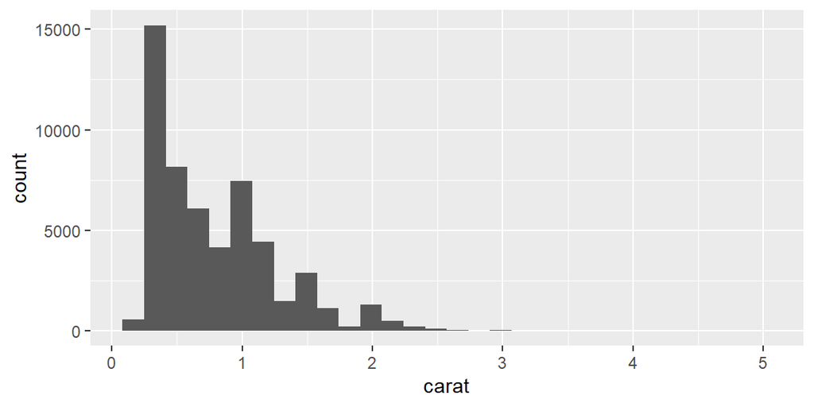

```r
g <- ggplot(data = diamonds, mapping = aes(x = carat))

g +
  geom_histogram()
```

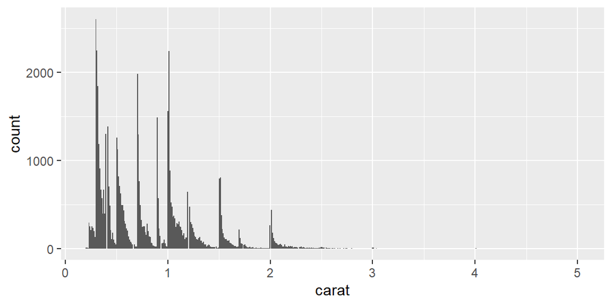

```r
g +
      geom_histogram(bins = 500)
```

```r
    fivenum(diamonds$carat)
```

```
## [1] 0.20 0.40 0.70 1.04 5.01
```

```r
    mean(diamonds$carat)
```

```
## [1] 0.7979397
```

```r
    sd(diamonds$carat)
```

```
## [1] 0.4740112
```

## 7.2 Categorical: Use a bar chart. Or just a table of *proportions* (`table()` then `prop.table()`).

```r
    ggplot(diamonds, aes(x = color, y = ..)) +
      geom_bar(aes(y = ..count.. / sum(..count..))) +
      ylab("Proportion")
```

[output not shown]

Another methods: 1.

```r
    ggplot(diamonds, aes(x = color, y = ..count../sum(..count..))) +
      geom_bar() +
      ylab("Proportion")
```

[output not shown]

```r
    diamonds %>%
      count(color) %>%
      mutate(prop = n/nrow(diamonds)) -> proportion

    ggplot(proportion,  aes(x = color, y = prop)) +
      geom_bar(stat = "identity") +
      ylab("Proportion")
```

[output not shown]

## 7.3 - Quantitative vs Quantitative: Use a scatterplot.

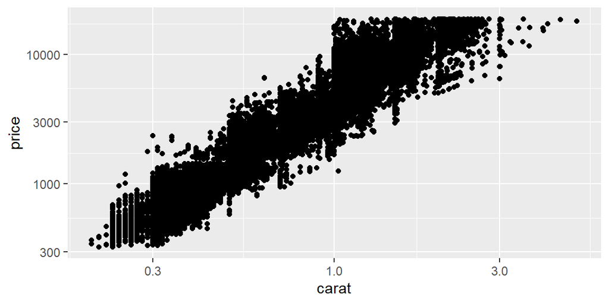

```r
    ggplot(diamonds, aes(x = carat, y = price)) +
      geom_point() +
      scale_y_log10() +
      scale_x_log10()
```

```r
    cor(diamonds$carat, diamonds$price)
```

```
## [1] 0.9215913
```

```r
    ## cor(diamonds$carat, diamonds$price, method = "kendall")
```

## 7.4 Categorical vs Quantitative: Use a boxplot

```
- For which levels of the categorical variable is the quantitative variable
  higher or lower?
- For which levels is the quantitative variable more spread out?
- Aggregated means, medians, standard deviations, quantiles
```

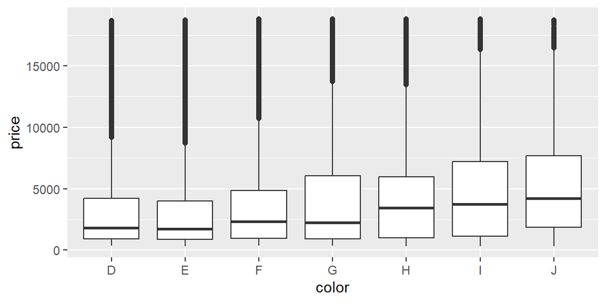

```r
    ggplot(diamonds, aes(x = color, y = price)) +
      geom_boxplot()
```

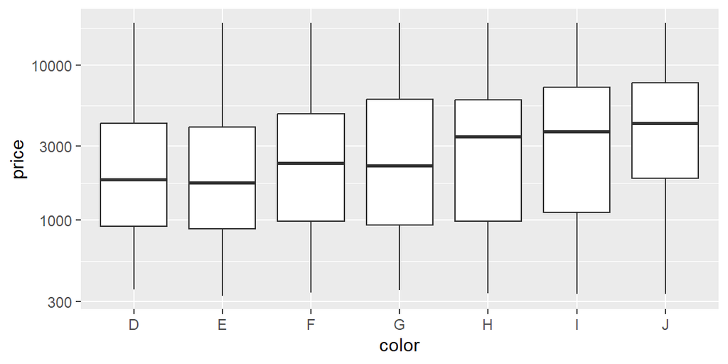

```r
    ggplot(diamonds, aes(x = color, y = price)) +
      geom_boxplot() +
      scale_y_log10()
```

## 7.5 Categorical vs Categorical: Use a mosaic plot or a count plot

```
- For which pairs of values of the categorical variables are there the most number of units?
- Does the conditional distribution of a categorical variable change
  at different levels of the other categorical variable?
- `prop.table()`
```

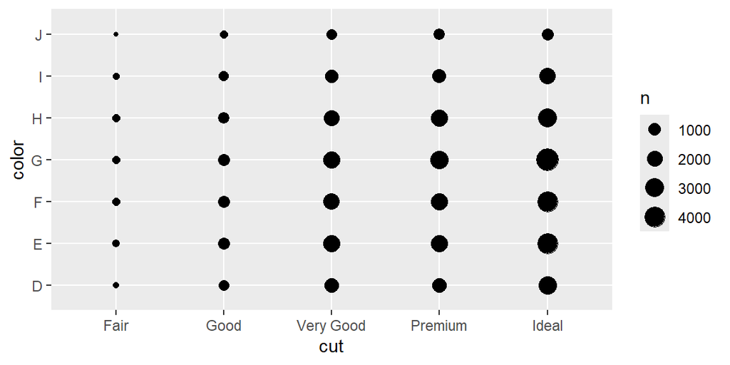

```r
    ## Only gives you the bivariate distribution
    ggplot(diamonds, aes(x = cut, y = color)) +
      geom_count()
```

If you can’t interpret a graph, then there is useless to darw it!

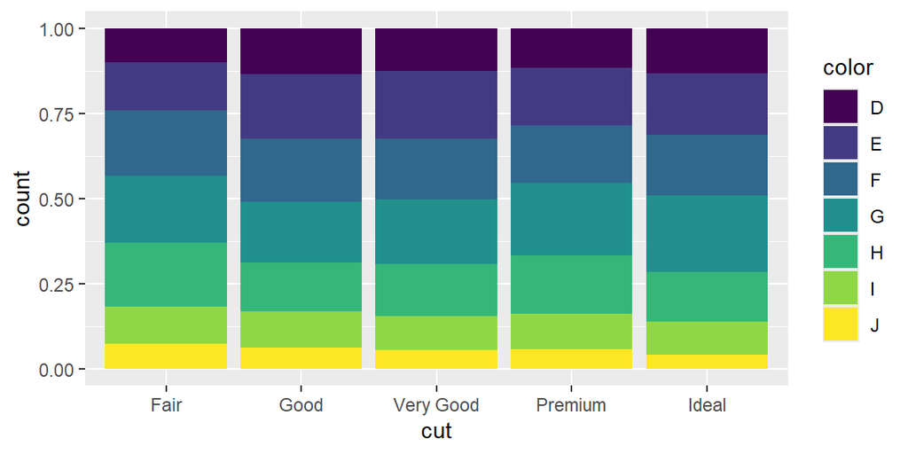

```r
   ## Gives you the conditional distributions of color given cut
    ggplot(diamonds, aes(x = cut, fill = color)) +
      geom_bar(position = "fill")
```

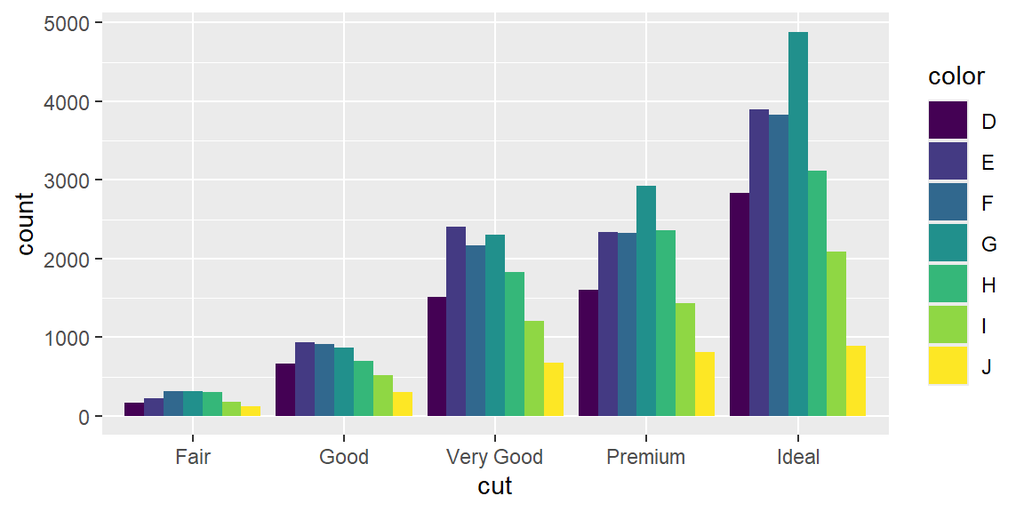

```r
   ## Gives you the conditional distributions of color given cut
    ggplot(diamonds, aes(x = cut, fill = color)) +
      geom_bar(position = "dodge")
```

There are different boxes and when you look at the area of each box it gives the idea of the proportion of combinations of `cut` and `color`

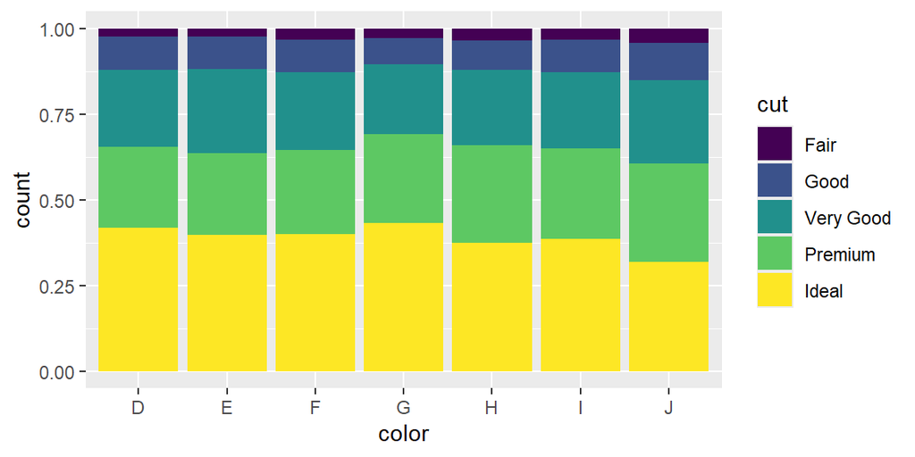

```r
    ## Gives you the conditional distributions of cut given color
    ggplot(diamonds, aes(x = color, fill = cut)) +
      geom_bar(position = "fill")
```

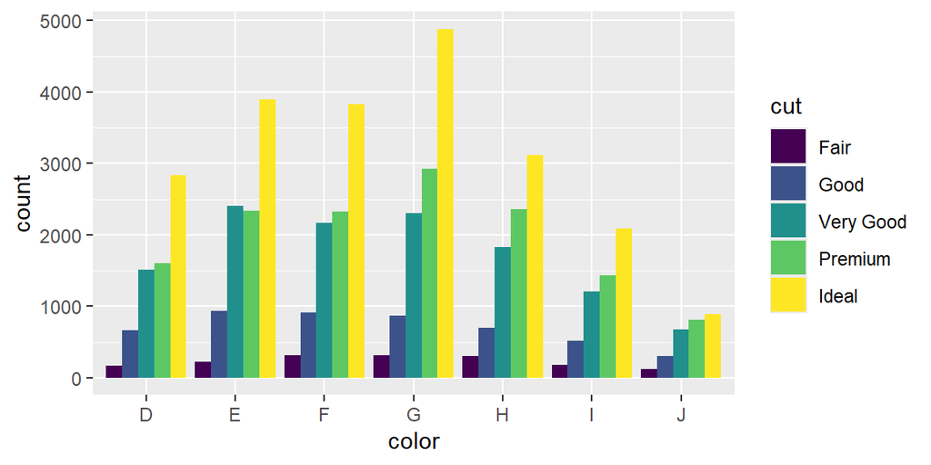

```r
    ## Gives you the conditional distributions of cut given color
    ggplot(diamonds, aes(x = color, fill = cut)) +
      geom_bar(position = "dodge")
```

```r
    ## Bivariate Distribution
    prop.table(table(diamonds$color, diamonds$cut))
```

```
##
##            Fair        Good   Very Good     Premium       Ideal
##   D 0.003021876 0.012272896 0.028049685 0.029718205 0.052539859
##   E 0.004152762 0.017296997 0.044493882 0.043325918 0.072358176
##   F 0.005784205 0.016852058 0.040118650 0.043214683 0.070930664
##   G 0.005821283 0.016147571 0.042621431 0.054208380 0.090545050
##   H 0.005617353 0.013014461 0.033815350 0.043752317 0.057749351
##   I 0.003244346 0.009677419 0.022321098 0.026473860 0.038802373
##   J 0.002206155 0.005691509 0.012569522 0.014979607 0.016611049
```

```r
    ##  Conditional distributions of column variable conditional on row variable
    prop.table(table(diamonds$color, diamonds$cut), margin = 1)
```

```
##
##           Fair       Good  Very Good    Premium      Ideal
##   D 0.02405904 0.09771218 0.22332103 0.23660517 0.41830258
##   E 0.02286414 0.09523323 0.24497295 0.23854241 0.39838726
##   F 0.03269755 0.09526305 0.22678684 0.24428841 0.40096416
##   G 0.02780730 0.07713425 0.20359547 0.25894439 0.43251860
##   H 0.03648844 0.08453757 0.21965318 0.28420039 0.37512042
##   I 0.03227591 0.09627444 0.22205828 0.26337145 0.38601992
##   J 0.04237892 0.10933048 0.24145299 0.28774929 0.31908832
```

```r
    ## Conditional distributions of row variable conditional on column variable
    prop.table(table(diamonds$color, diamonds$cut), margin = 2)
```

```
##
##           Fair       Good  Very Good    Premium      Ideal
##   D 0.10124224 0.13493681 0.12522761 0.11623523 0.13150202
##   E 0.13913043 0.19017530 0.19864261 0.16945834 0.18110529
##   F 0.19378882 0.18528333 0.17910942 0.16902328 0.17753237
##   G 0.19503106 0.17753771 0.19028307 0.21202233 0.22662521
##   H 0.18819876 0.14309009 0.15096838 0.17112610 0.14454086
##   I 0.10869565 0.10640033 0.09965238 0.10354579 0.09711846
##   J 0.07391304 0.06257644 0.05611654 0.05858893 0.04157580
```

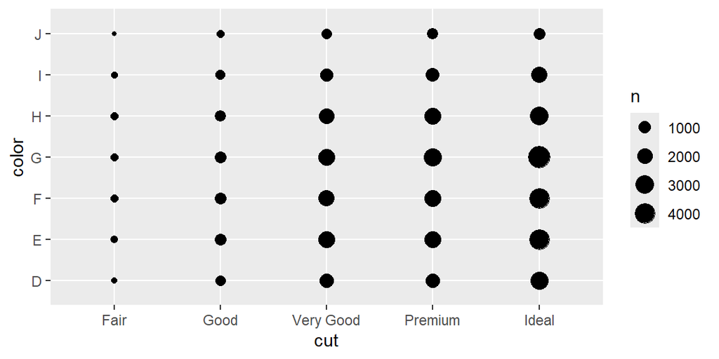

```r
    ## Only gives you the bivariate distribution
    ggplot(diamonds, aes(x = cut, y = color)) +
      geom_count()
```

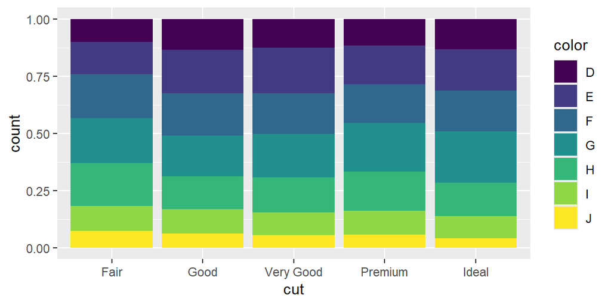

```r
    ## Gives you the conditional distributions of color given cut
    ggplot(diamonds, aes(x = cut, fill = color)) +
      geom_bar(position = "fill")
```

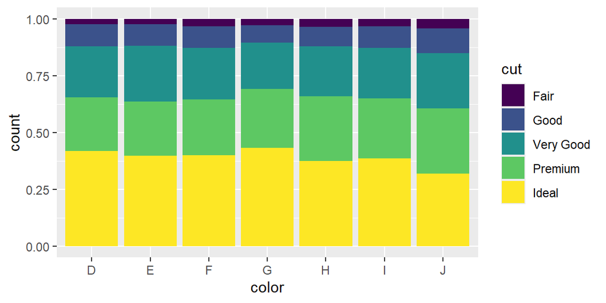

```r
    ## Gives you the conditional distributions of cut given color
    ggplot(diamonds, aes(x = color, fill = cut)) +
      geom_bar(position = "fill")
```

```r
    ## Bivariate Distribution
    prop.table(table(diamonds$color, diamonds$cut))
```

```
##
##            Fair        Good   Very Good     Premium       Ideal
##   D 0.003021876 0.012272896 0.028049685 0.029718205 0.052539859
##   E 0.004152762 0.017296997 0.044493882 0.043325918 0.072358176
##   F 0.005784205 0.016852058 0.040118650 0.043214683 0.070930664
##   G 0.005821283 0.016147571 0.042621431 0.054208380 0.090545050
##   H 0.005617353 0.013014461 0.033815350 0.043752317 0.057749351
##   I 0.003244346 0.009677419 0.022321098 0.026473860 0.038802373
##   J 0.002206155 0.005691509 0.012569522 0.014979607 0.016611049
```

```r
    ##  Conditional distributions of column variable conditional on row variable
    prop.table(table(diamonds$color, diamonds$cut), margin = 1)
```

```
##
##           Fair       Good  Very Good    Premium      Ideal
##   D 0.02405904 0.09771218 0.22332103 0.23660517 0.41830258
##   E 0.02286414 0.09523323 0.24497295 0.23854241 0.39838726
##   F 0.03269755 0.09526305 0.22678684 0.24428841 0.40096416
##   G 0.02780730 0.07713425 0.20359547 0.25894439 0.43251860
##   H 0.03648844 0.08453757 0.21965318 0.28420039 0.37512042
##   I 0.03227591 0.09627444 0.22205828 0.26337145 0.38601992
##   J 0.04237892 0.10933048 0.24145299 0.28774929 0.31908832
```

```r
    ## Conditional distributions of row variable conditional on column variable
    prop.table(table(diamonds$color, diamonds$cut), margin = 2)
```

```
##
##           Fair       Good  Very Good    Premium      Ideal
##   D 0.10124224 0.13493681 0.12522761 0.11623523 0.13150202
##   E 0.13913043 0.19017530 0.19864261 0.16945834 0.18110529
##   F 0.19378882 0.18528333 0.17910942 0.16902328 0.17753237
##   G 0.19503106 0.17753771 0.19028307 0.21202233 0.22662521
##   H 0.18819876 0.14309009 0.15096838 0.17112610 0.14454086
##   I 0.10869565 0.10640033 0.09965238 0.10354579 0.09711846
##   J 0.07391304 0.06257644 0.05611654 0.05858893 0.04157580
```

# 8 Parsers

- Change character vectors into other types using parsers.
- Suppose you have the following data frame

```r
    suppressPackageStartupMessages(library(tidyverse))
    dfdat <- tribble(
      ~date,        ~time,      ~number, ~factor, ~logical,
      ##----------  ----------  -------  -------  --------
      "12-01-1988", "10:10:02", "2",     "A",     "TRUE",
      "11-12-1987", "11:10:57", "4",     "A",     "TRUE",
      "02-03-1989", "10:10:25", "6",     "B",     "FALSE",
      "06-03-1982", "22:10:55", "2",     "B",     "TRUE",
      "09-21-1981", "10:10:02", "1",     "A",     "FALSE"
      )
    dfdat
```

```
## # A tibble: 5 × 5
##   date       time     number factor logical
##   <chr>      <chr>    <chr>  <chr>  <chr>
## 1 12-01-1988 10:10:02 2      A      TRUE
## 2 11-12-1987 11:10:57 4      A      TRUE
## 3 02-03-1989 10:10:25 6      B      FALSE
## 4 06-03-1982 22:10:55 2      B      TRUE
## 5 09-21-1981 10:10:02 1      A      FALSE
```

- How do we convert the characters to the types we want? Parse!

## 8.1 Parsing dates with `parse_date()` and `parse_date_time()`.

- `parse_date()` and `parse_datetime()` are very similar, but internally count the time from 1970-01-01 in terms of either days or seconds.

```r
    parse_date("2018-01-02")
```

```
## [1] "2018-01-02"
```

```r
    parse_datetime("2018-01-02")
```

```
## [1] "2018-01-02 UTC"
```

- They expect the format `"YYYY-MM-DD"`. If your date is in a different format, you need to use the `format` argument.

```r
    ## Parsing Failure
    parse_date("02/01/2018")
```

```
## [1] NA
```

```r
    ## Parsing Success!
    parse_date("02/01/2018", format = "%m/%d/%Y")
```

```
## [1] "2018-02-01"
```

- We added slashes so that R can know how the date is formatted.
- Format options:
  - `%d`: 2-digit representation of day (but can recognize single digits sometimes)
  - `%m`: 2-digit representation of month
  - `%b`: Abbreviation of month (“Jan”)
  - `%B`: Full month name (“January”)
  - `%y`: 2-digit representation of year
  - `%Y`: 4-digit representation of year
- Another example:

```r
    parse_date("January 1, 2018", format = "%B %d, %Y")
```

```
## [1] "2018-01-01"
```

- Our example:

```r
    dfdat %>%
      mutate(date = parse_date(date, format = "%m-%d-%Y"))
```

```
## # A tibble: 5 × 5
##   date       time     number factor logical
##   <date>     <chr>    <chr>  <chr>  <chr>
## 1 1988-12-01 10:10:02 2      A      TRUE
## 2 1987-11-12 11:10:57 4      A      TRUE
## 3 1989-02-03 10:10:25 6      B      FALSE
## 4 1982-06-03 22:10:55 2      B      TRUE
## 5 1981-09-21 10:10:02 1      A      FALSE
```

## 8.2 Parsing Times

`parse_time()` is very similar to `parse_date()` except the format argument.

– %H: Hour in 0-23 format – %I: Hour in 0-12 format – %p: am/pm – %M: minutes – %S: integer seconds – %OS: double seconds – %Z: Time zone (need nuance here)

```r
    dfdat %>%
      mutate(time = parse_time(time, format = "%H:%M:%S"))
```

```
## # A tibble: 5 × 5
##   date       time     number factor logical
##   <chr>      <time>   <chr>  <chr>  <chr>
## 1 12-01-1988 10:10:02 2      A      TRUE
## 2 11-12-1987 11:10:57 4      A      TRUE
## 3 02-03-1989 10:10:25 6      B      FALSE
## 4 06-03-1982 22:10:55 2      B      TRUE
## 5 09-21-1981 10:10:02 1      A      FALSE
```

## 8.3 Parsing Numbers

- `parse_double()` and `parse_integer()` expect strict numbers and will fail if there is anything non-number-like.

```r
    parse_double("2.11")
```

```
## [1] 2.11
```

```r
    parse_double("$2.11")
```

```
## [1] NA
## attr(,"problems")
## # A tibble: 1 × 4
##     row   col expected actual
##   <int> <int> <chr>    <chr>
## 1     1    NA a double $2.11
```

```r
    parse_integer("2")
```

```
## [1] 2
```

```r
    parse_integer("2%")
```

```
## [1] NA
## attr(,"problems")
## # A tibble: 1 × 4
##     row   col expected               actual
##   <int> <int> <chr>                  <chr>
## 1     1    NA no trailing characters 2%
```

- `parse_number()` removes non-numeric characters.

```r
    parse_number("$2.11")
```

```
## [1] 2.11
```

```r
    parse_number("2%")
```

```
## [1] 2
```

- You can change the grouping variable from “,” to “.” with

```r
    parse_number("2.555,11",
                 locale = locale(grouping_mark = ".",
                                 decimal_mark = ","))
```

```
## [1] 2555.11
```

```r
    parse_number("25.655,11",
                 locale = locale(grouping_mark = ".",
                                 decimal_mark = ","))
```

```
## [1] 25655.11
```

## 8.4 Parsing other types

- `parse_logical()` and `parse_factor()` and `parse_string()` are pretty self-explanatory. What happened in the following code?

```r
    dfdat %>%
      mutate(factor = parse_factor(factor))
```

```
## # A tibble: 5 × 5
##   date       time     number factor logical
##   <chr>      <chr>    <chr>  <fct>  <chr>
## 1 12-01-1988 10:10:02 2      A      TRUE
## 2 11-12-1987 11:10:57 4      A      TRUE
## 3 02-03-1989 10:10:25 6      B      FALSE
## 4 06-03-1982 22:10:55 2      B      TRUE
## 5 09-21-1981 10:10:02 1      A      FALSE
```

How about this one?

```r
    dfdat %>%
      mutate(logical = parse_logical(logical))
```

```
## # A tibble: 5 × 5
##   date       time     number factor logical
##   <chr>      <chr>    <chr>  <chr>  <lgl>
## 1 12-01-1988 10:10:02 2      A      TRUE
## 2 11-12-1987 11:10:57 4      A      TRUE
## 3 02-03-1989 10:10:25 6      B      FALSE
## 4 06-03-1982 22:10:55 2      B      TRUE
## 5 09-21-1981 10:10:02 1      A      FALSE
```

## 8.5 Parsing and readr

```r
    read_csv("../data/estate.csv")
```

```
## # A tibble: 522 × 12
##     Price  Area   Bed  Bath    AC Garage  Pool  Year Quality Style   Lot Highway
##     <dbl> <dbl> <dbl> <dbl> <dbl>  <dbl> <dbl> <dbl> <chr>   <dbl> <dbl>   <dbl>
##  1 360000  3032     4     4     1      2     0  1972 Medium      1 22221       0
##  2 340000  2058     4     2     1      2     0  1976 Medium      1 22912       0
##  3 250000  1780     4     3     1      2     0  1980 Medium      1 21345       0
##  4 205500  1638     4     2     1      2     0  1963 Medium      1 17342       0
##  5 275500  2196     4     3     1      2     0  1968 Medium      7 21786       0
##  6 248000  1966     4     3     1      5     1  1972 Medium      1 18902       0
##  7 229900  2216     3     2     1      2     0  1972 Medium      7 18639       0
##  8 150000  1597     2     1     1      1     0  1955 Medium      1 22112       0
##  9 195000  1622     3     2     1      2     0  1975 Low         1 14321       0
## 10 160000  1976     3     3     0      1     0  1918 Low         1 32358       0
## # ℹ 512 more rows
```

- When you specify `col_types` in `read_csv()`, those are wrappers for parsers.

```r
    read_csv("../data/estate.csv",
             col_types = cols(
               Price   = col_double(),
               Area    = col_double(),
               Bed     = col_double(),
               Bath    = col_double(),
               AC      = col_logical(),
               Garage  = col_double(),
               Pool    = col_logical(),
               Year    = col_double(),
               Quality = col_factor(),
               Style   = col_factor(),
               Lot     = col_double(),
               Highway = col_logical()
               )) ->
      new_estate
    new_estate
```

```
## # A tibble: 522 × 12
##     Price  Area   Bed  Bath AC    Garage Pool   Year Quality Style   Lot Highway
##     <dbl> <dbl> <dbl> <dbl> <lgl>  <dbl> <lgl> <dbl> <fct>   <fct> <dbl> <lgl>
##  1 360000  3032     4     4 TRUE       2 FALSE  1972 Medium  1     22221 FALSE
##  2 340000  2058     4     2 TRUE       2 FALSE  1976 Medium  1     22912 FALSE
##  3 250000  1780     4     3 TRUE       2 FALSE  1980 Medium  1     21345 FALSE
##  4 205500  1638     4     2 TRUE       2 FALSE  1963 Medium  1     17342 FALSE
##  5 275500  2196     4     3 TRUE       2 FALSE  1968 Medium  7     21786 FALSE
##  6 248000  1966     4     3 TRUE       5 TRUE   1972 Medium  1     18902 FALSE
##  7 229900  2216     3     2 TRUE       2 FALSE  1972 Medium  7     18639 FALSE
##  8 150000  1597     2     1 TRUE       1 FALSE  1955 Medium  1     22112 FALSE
##  9 195000  1622     3     2 TRUE       2 FALSE  1975 Low     1     14321 FALSE
## 10 160000  1976     3     3 FALSE      1 FALSE  1918 Low     1     32358 FALSE
## # ℹ 512 more rows
```

# 9 DBPLYR

- dplyr basically implements the most common actions in SQL (but SQL can do more).
- We’ll use a soccer dataset to demonstrate how to use dplyr (instead of SQL) syntax when interacting with a database. Download and unzip the soccer database from https://dcgerard.github.io/stat_412_612/data.html.
- We’ll use the dbplyr package to interact with databases.

```r
    library(tidyverse)
    library(dbplyr)
```

- dbplyr allows you to work with databases as if you are using dplyr.
- You’ll also need to install the RSQLite package. There are different ways to create/access/update/delete data from relational databases, and RSQLite provides an R interface for one of these ways.

```r
    install.packages("RSQLite")
```

```r
    library(RSQLite)
```

- If your database uses a different engine, you’ll need to download other packages to interact with it (see [Introduction to dbplyr](https://cran.r-project.org/web/packages/dbplyr/vignettes/dbplyr.html))
- First, we’ll tell R where the database is using `dbConnect()`, (you might need to change the path).

```r
    con <- dbConnect(drv = SQLite(), dbname = "../data/soccer.sqlite")
```

- Now we’ll list the data frames available in the connection we just created.

```r
    dbListTables(con)
```

```
## [1] "Country"           "League"            "Match"
## [4] "Player"            "Player_Attributes" "Team"
## [7] "Team_Attributes"   "sqlite_sequence"
```

- Use `tbl()` to make a reference to the tables in `con`.

```r
    Team_db    <- tbl(con, "Team")
Team_db
```

```
## # Source:   table<`Team`> [?? x 5]
## # Database: sqlite 3.46.0 [C:\Users\semiyari\Desktop\Personal\AU\DATA613\Spring24\data\soccer.sqlite]
##       id team_api_id team_fifa_api_id team_long_name    team_short_name
##    <int>       <int>            <int> <chr>             <chr>
##  1     1        9987              673 KRC Genk          GEN
##  2     2        9993              675 Beerschot AC      BAC
##  3     3       10000            15005 SV Zulte-Waregem  ZUL
##  4     4        9994             2007 Sporting Lokeren  LOK
##  5     5        9984             1750 KSV Cercle Brugge CEB
##  6     6        8635              229 RSC Anderlecht    AND
##  7     7        9991              674 KAA Gent          GEN
##  8     8        9998             1747 RAEC Mons         MON
##  9     9        7947               NA FCV Dender EH     DEN
## 10    10        9985              232 Standard de Liège STL
## # ℹ more rows
```

```r
    Team_at_db <- tbl(con, "Team_Attributes")
Team_at_db
```

```
## # Source:   table<`Team_Attributes`> [?? x 25]
## # Database: sqlite 3.46.0 [C:\Users\semiyari\Desktop\Personal\AU\DATA613\Spring24\data\soccer.sqlite]
##       id team_fifa_api_id team_api_id date                buildUpPlaySpeed
##    <int>            <int>       <int> <chr>                          <int>
##  1     1              434        9930 2010-02-22 00:00:00               60
##  2     2              434        9930 2014-09-19 00:00:00               52
##  3     3              434        9930 2015-09-10 00:00:00               47
##  4     4               77        8485 2010-02-22 00:00:00               70
##  5     5               77        8485 2011-02-22 00:00:00               47
##  6     6               77        8485 2012-02-22 00:00:00               58
##  7     7               77        8485 2013-09-20 00:00:00               62
##  8     8               77        8485 2014-09-19 00:00:00               58
##  9     9               77        8485 2015-09-10 00:00:00               59
## 10    10              614        8576 2010-02-22 00:00:00               60
## # ℹ more rows
## # ℹ 20 more variables: buildUpPlaySpeedClass <chr>, buildUpPlayDribbling <int>,
## #   buildUpPlayDribblingClass <chr>, buildUpPlayPassing <int>,
## #   buildUpPlayPassingClass <chr>, buildUpPlayPositioningClass <chr>,
## #   chanceCreationPassing <int>, chanceCreationPassingClass <chr>,
## #   chanceCreationCrossing <int>, chanceCreationCrossingClass <chr>,
## #   chanceCreationShooting <int>, chanceCreationShootingClass <chr>, …
```

```r
    Country_db <- tbl(con, "Country")
Country_db
```

```
## # Source:   table<`Country`> [?? x 2]
## # Database: sqlite 3.46.0 [C:\Users\semiyari\Desktop\Personal\AU\DATA613\Spring24\data\soccer.sqlite]
##       id name
##    <int> <chr>
##  1     1 Belgium
##  2  1729 England
##  3  4769 France
##  4  7809 Germany
##  5 10257 Italy
##  6 13274 Netherlands
##  7 15722 Poland
##  8 17642 Portugal
##  9 19694 Scotland
## 10 21518 Spain
## # ℹ more rows
```

```r
    League_db  <- tbl(con, "League")
League_db
```

```
## # Source:   table<`League`> [?? x 3]
## # Database: sqlite 3.46.0 [C:\Users\semiyari\Desktop\Personal\AU\DATA613\Spring24\data\soccer.sqlite]
##       id country_id name
##    <int>      <int> <chr>
##  1     1          1 Belgium Jupiler League
##  2  1729       1729 England Premier League
##  3  4769       4769 France Ligue 1
##  4  7809       7809 Germany 1. Bundesliga
##  5 10257      10257 Italy Serie A
##  6 13274      13274 Netherlands Eredivisie
##  7 15722      15722 Poland Ekstraklasa
##  8 17642      17642 Portugal Liga ZON Sagres
##  9 19694      19694 Scotland Premier League
## 10 21518      21518 Spain LIGA BBVA
## # ℹ more rows
```

```r
    Match_db   <- tbl(con, "Match")
Match_db
```

```
## # Source:   table<`Match`> [?? x 115]
## # Database: sqlite 3.46.0 [C:\Users\semiyari\Desktop\Personal\AU\DATA613\Spring24\data\soccer.sqlite]
##       id country_id league_id season   stage date  match_api_id home_team_api_id
##    <int>      <int>     <int> <chr>    <int> <chr>        <int>            <int>
##  1     1          1         1 2008/20…     1 2008…       492473             9987
##  2     2          1         1 2008/20…     1 2008…       492474            10000
##  3     3          1         1 2008/20…     1 2008…       492475             9984
##  4     4          1         1 2008/20…     1 2008…       492476             9991
##  5     5          1         1 2008/20…     1 2008…       492477             7947
##  6     6          1         1 2008/20…     1 2008…       492478             8203
##  7     7          1         1 2008/20…     1 2008…       492479             9999
##  8     8          1         1 2008/20…     1 2008…       492480             4049
##  9     9          1         1 2008/20…     1 2008…       492481            10001
## 10    10          1         1 2008/20…    10 2008…       492564             8342
## # ℹ more rows
## # ℹ 107 more variables: away_team_api_id <int>, home_team_goal <int>,
## #   away_team_goal <int>, home_player_X1 <int>, home_player_X2 <int>,
## #   home_player_X3 <int>, home_player_X4 <int>, home_player_X5 <int>,
## #   home_player_X6 <int>, home_player_X7 <int>, home_player_X8 <int>,
## #   home_player_X9 <int>, home_player_X10 <int>, home_player_X11 <int>,
## #   away_player_X1 <int>, away_player_X2 <int>, away_player_X3 <int>, …
```

- We can now interact with all of these data frames mostly like if they were in memory (with some limitations).

```r
    head(Country_db)
```

```
## # Source:   SQL [6 x 2]
## # Database: sqlite 3.46.0 [C:\Users\semiyari\Desktop\Personal\AU\DATA613\Spring24\data\soccer.sqlite]
##      id name
##   <int> <chr>
## 1     1 Belgium
## 2  1729 England
## 3  4769 France
## 4  7809 Germany
## 5 10257 Italy
## 6 13274 Netherlands
```

```r
    head(Match_db)
```

```
## # Source:   SQL [6 x 115]
## # Database: sqlite 3.46.0 [C:\Users\semiyari\Desktop\Personal\AU\DATA613\Spring24\data\soccer.sqlite]
##      id country_id league_id season    stage date  match_api_id home_team_api_id
##   <int>      <int>     <int> <chr>     <int> <chr>        <int>            <int>
## 1     1          1         1 2008/2009     1 2008…       492473             9987
## 2     2          1         1 2008/2009     1 2008…       492474            10000
## 3     3          1         1 2008/2009     1 2008…       492475             9984
## 4     4          1         1 2008/2009     1 2008…       492476             9991
## 5     5          1         1 2008/2009     1 2008…       492477             7947
## 6     6          1         1 2008/2009     1 2008…       492478             8203
## # ℹ 107 more variables: away_team_api_id <int>, home_team_goal <int>,
## #   away_team_goal <int>, home_player_X1 <int>, home_player_X2 <int>,
## #   home_player_X3 <int>, home_player_X4 <int>, home_player_X5 <int>,
## #   home_player_X6 <int>, home_player_X7 <int>, home_player_X8 <int>,
## #   home_player_X9 <int>, home_player_X10 <int>, home_player_X11 <int>,
## #   away_player_X1 <int>, away_player_X2 <int>, away_player_X3 <int>,
## #   away_player_X4 <int>, away_player_X5 <int>, away_player_X6 <int>, …
```

```r
    Match_db %>%
      select(id:away_team_goal)
```

```
## # Source:   SQL [?? x 11]
## # Database: sqlite 3.46.0 [C:\Users\semiyari\Desktop\Personal\AU\DATA613\Spring24\data\soccer.sqlite]
##       id country_id league_id season   stage date  match_api_id home_team_api_id
##    <int>      <int>     <int> <chr>    <int> <chr>        <int>            <int>
##  1     1          1         1 2008/20…     1 2008…       492473             9987
##  2     2          1         1 2008/20…     1 2008…       492474            10000
##  3     3          1         1 2008/20…     1 2008…       492475             9984
##  4     4          1         1 2008/20…     1 2008…       492476             9991
##  5     5          1         1 2008/20…     1 2008…       492477             7947
##  6     6          1         1 2008/20…     1 2008…       492478             8203
##  7     7          1         1 2008/20…     1 2008…       492479             9999
##  8     8          1         1 2008/20…     1 2008…       492480             4049
##  9     9          1         1 2008/20…     1 2008…       492481            10001
## 10    10          1         1 2008/20…    10 2008…       492564             8342
## # ℹ more rows
## # ℹ 3 more variables: away_team_api_id <int>, home_team_goal <int>,
## #   away_team_goal <int>
```

```r
    glimpse(Match_db)
```

```
## Rows: ??
## Columns: 115
## Database: sqlite 3.46.0 [C:\Users\semiyari\Desktop\Personal\AU\DATA613\Spring24\data\soccer.sqlite]
## $ id               <int> 1, 2, 3, 4, 5, 6, 7, 8, 9, 10, 11, 12, 13, 14, 15, 16…
## $ country_id       <int> 1, 1, 1, 1, 1, 1, 1, 1, 1, 1, 1, 1, 1, 1, 1, 1, 1, 1,…
## $ league_id        <int> 1, 1, 1, 1, 1, 1, 1, 1, 1, 1, 1, 1, 1, 1, 1, 1, 1, 1,…
## $ season           <chr> "2008/2009", "2008/2009", "2008/2009", "2008/2009", "…
## $ stage            <int> 1, 1, 1, 1, 1, 1, 1, 1, 1, 10, 10, 10, 10, 10, 10, 10…
## $ date             <chr> "2008-08-17 00:00:00", "2008-08-16 00:00:00", "2008-0…
## $ match_api_id     <int> 492473, 492474, 492475, 492476, 492477, 492478, 49247…
## $ home_team_api_id <int> 9987, 10000, 9984, 9991, 7947, 8203, 9999, 4049, 1000…
## $ away_team_api_id <int> 9993, 9994, 8635, 9998, 9985, 8342, 8571, 9996, 9986,…
## $ home_team_goal   <int> 1, 0, 0, 5, 1, 1, 2, 1, 1, 4, 1, 0, 0, 2, 1, 0, 1, 1,…
## $ away_team_goal   <int> 1, 0, 3, 0, 3, 1, 2, 2, 0, 1, 2, 2, 0, 2, 2, 1, 3, 3,…
## $ home_player_X1   <int> NA, NA, NA, NA, NA, NA, NA, NA, NA, NA, NA, NA, NA, N…
```

[output cut: 103 more lines]

```r
    names(Match_db) ## won't work
```

```
## ! The `names()` method of <tbl_lazy> is for internal use only.
## ℹ Did you mean `colnames()`?
```

```
## [1] "src"        "lazy_query"
```

- Once you select the variables you want and the observations you want, you should use `collect()` to get the data frame into memory so that you can have all of the functionality of R (e.g., `gather()` and `spread()` will only work on in-memory data frames).

```r
    Match_db %>%
      select(id:away_team_goal) %>%
      collect() ->
      Match
Match
```

```
## # A tibble: 25,979 × 11
##       id country_id league_id season   stage date  match_api_id home_team_api_id
##    <int>      <int>     <int> <chr>    <int> <chr>        <int>            <int>
##  1     1          1         1 2008/20…     1 2008…       492473             9987
##  2     2          1         1 2008/20…     1 2008…       492474            10000
##  3     3          1         1 2008/20…     1 2008…       492475             9984
##  4     4          1         1 2008/20…     1 2008…       492476             9991
##  5     5          1         1 2008/20…     1 2008…       492477             7947
##  6     6          1         1 2008/20…     1 2008…       492478             8203
##  7     7          1         1 2008/20…     1 2008…       492479             9999
##  8     8          1         1 2008/20…     1 2008…       492480             4049
##  9     9          1         1 2008/20…     1 2008…       492481            10001
## 10    10          1         1 2008/20…    10 2008…       492564             8342
## # ℹ 25,969 more rows
## # ℹ 3 more variables: away_team_api_id <int>, home_team_goal <int>,
## #   away_team_goal <int>
```

```r
    Team_db %>%
      collect() ->
      Team
Team
```

```
## # A tibble: 299 × 5
##       id team_api_id team_fifa_api_id team_long_name    team_short_name
##    <int>       <int>            <int> <chr>             <chr>
##  1     1        9987              673 KRC Genk          GEN
##  2     2        9993              675 Beerschot AC      BAC
##  3     3       10000            15005 SV Zulte-Waregem  ZUL
##  4     4        9994             2007 Sporting Lokeren  LOK
##  5     5        9984             1750 KSV Cercle Brugge CEB
##  6     6        8635              229 RSC Anderlecht    AND
##  7     7        9991              674 KAA Gent          GEN
##  8     8        9998             1747 RAEC Mons         MON
##  9     9        7947               NA FCV Dender EH     DEN
## 10    10        9985              232 Standard de Liège STL
## # ℹ 289 more rows
```

```r
    Country_db %>%
      collect() ->
      Country

Country
```

```
## # A tibble: 11 × 2
##       id name
##    <int> <chr>
##  1     1 Belgium
##  2  1729 England
##  3  4769 France
##  4  7809 Germany
##  5 10257 Italy
##  6 13274 Netherlands
##  7 15722 Poland
##  8 17642 Portugal
##  9 19694 Scotland
## 10 21518 Spain
## 11 24558 Switzerland
```

- The following will return a data frame telling you where each team is from.

```r
    Match %>%
      select(country_id, home_team_api_id, away_team_api_id) %>%
      gather(-country_id, key = "home_away", value = "team_api_id") %>%
      select(-home_away) %>%
      distinct() %>%
      left_join(Team, by = "team_api_id") %>%
      left_join(Country, by = c("country_id" = "id")) %>%
      select(team_long_name, team_short_name, name) %>%
      rename(country_name = name)
```

```
## # A tibble: 299 × 3
##    team_long_name    team_short_name country_name
##    <chr>             <chr>           <chr>
##  1 KRC Genk          GEN             Belgium
##  2 SV Zulte-Waregem  ZUL             Belgium
##  3 KSV Cercle Brugge CEB             Belgium
##  4 KAA Gent          GEN             Belgium
##  5 FCV Dender EH     DEN             Belgium
##  6 KV Mechelen       MEC             Belgium
##  7 KSV Roeselare     ROS             Belgium
##  8 Tubize            TUB             Belgium
##  9 KVC Westerlo      WES             Belgium
## 10 Club Brugge KV    CLB             Belgium
## # ℹ 289 more rows
```

## 9.1 Joining

- Many datasets have more than two data frames.
- These data frames are often connected (rows in one correspond to rows in another)
- Consider the data in the nycflights13 package.

  ```r
  library(nycflights13)
  ```

[figure not shown]

- For nycflights13:
  - `flights` connects to `planes` via a single variable, `tailnum`.
  - `flights` connects to `airlines` through the `carrier` variable.
  - `flights` connects to `airports` in two ways: via the `origin` and `dest` variables.
  - `flights` connects to `weather` via `origin` (the location), and `year`, `month`, `day` and `hour` (the time).
- Variables used to connect a pair of data frames are called **keys**.
- **Primary key**: Uniquely identifies an observation in its own table.
- **Foreign key**: Uniquely identifies an observation in another table.
- *Example*: `flights$tailnum` is a foreign key because it appears in the `flights` table where it matches each flight to a unique plane. There are multiple rows with the same `tailnum` in `flights`, so `flights$tailnum` is *not* a primary key.

```r
    flights %>%
      group_by(tailnum) %>%
      count() %>%
      filter(n > 1)
```

```
## # A tibble: 3,873 × 2
## # Groups:   tailnum [3,873]
##    tailnum     n
##    <chr>   <int>
##  1 D942DN      4
##  2 N0EGMQ    371
##  3 N10156    153
##  4 N102UW     48
##  5 N103US     46
##  6 N104UW     47
##  7 N10575    289
##  8 N105UW     45
##  9 N107US     41
## 10 N108UW     60
## # ℹ 3,863 more rows
```

## 9.2 Join Set-Up

- Suppose we have the following two data frames

[figure not shown]

```r
    x <- tribble(~key, ~val_x,
                 #---  ------
                 1,    "x1",
                 2,    "x2",
                 3,    "x3")
    y <- tribble(~key, ~val_y,
                 #---  ------
                 1,    "y1",
                 2,    "y2",
                 4,    "y3")
```

- A join connects rows of `x` to rows of `y`.

[figure not shown]

- E.g. match row `1` of `x` with row `1` of `y`, and row `2` of `x` with row `2` of `y`.

[figure not shown]

### 9.2.1 Inner Join

- `inner_join(x, y)` matches the rows of `x` with rows of `y` only when their keys are equal.

[figure not shown]

```r
    inner_join(x, y, by = "key")
```

```
## # A tibble: 2 × 3
##     key val_x val_y
##   <dbl> <chr> <chr>
## 1     1 x1    y1
## 2     2 x2    y2
```

- Keeps all rows that appear in *both* data frames.

### 9.2.2 Outer Join

- Keeps all rows that appear in *at least one* data frame.

[figure not shown]

- `left_join(x, y)` keeps all rows of `x`.

```r
    left_join(x, y, by = "key")
```

```
## # A tibble: 3 × 3
##     key val_x val_y
##   <dbl> <chr> <chr>
## 1     1 x1    y1
## 2     2 x2    y2
## 3     3 x3    <NA>
```

- `left_join()` is by far the most common joiner, and you should always use this unless you have a good reason not to.
- `right_join(x, y)` keeps all rows of `y`.

```r
    right_join(x, y, by = "key")
```

```
## # A tibble: 3 × 3
##     key val_x val_y
##   <dbl> <chr> <chr>
## 1     1 x1    y1
## 2     2 x2    y2
## 3     4 <NA>  y3
```

- `full_join(x, y)` keeps all rows of both.

```r
    full_join(x, y, by = "key")
```

```
## # A tibble: 4 × 3
##     key val_x val_y
##   <dbl> <chr> <chr>
## 1     1 x1    y1
## 2     2 x2    y2
## 3     3 x3    <NA>
## 4     4 <NA>  y3
```

### 9.2.3 Duplicate Keys

- If you have duplicate keys in one table, then the rows from the data frame where there is no duplication are copied multiple times in the new data frame.

[figure not shown]

  (useful for adding summary data to a table)

```r
    x_mult <- tribble(~key, ~val_x,
                      ##--  ------
                      1,    "x1",
                      2,    "x2",
                      2,    "x3",
                      1,    "x4")

    left_join(x_mult, y, by = "key")
```

```
## # A tibble: 4 × 3
##     key val_x val_y
##   <dbl> <chr> <chr>
## 1     1 x1    y1
## 2     2 x2    y2
## 3     2 x3    y2
## 4     1 x4    y1
```

- If you have duplicate keys in both (usually a mistake), then you get every possible combination of the values in x and y at the key values where there are duplications.

[figure not shown]

```r
    y_mult <- tribble(~key, ~val_y,
                      ##--  ------
                      1,    "y1",
                      2,    "y2",
                      2,    "y3",
                      1,    "y4")

    left_join(x_mult, y_mult, by = "key")
```

```
## # A tibble: 8 × 3
##     key val_x val_y
##   <dbl> <chr> <chr>
## 1     1 x1    y1
## 2     1 x1    y4
## 3     2 x2    y2
## 4     2 x2    y3
## 5     2 x3    y2
## 6     2 x3    y3
## 7     1 x4    y1
## 8     1 x4    y4
```

### 9.2.4 Filtering Joins

- `semi_join()` *keeps* all of the rows in `x` that have a match in `y` (but don’t add the variables of `y` to `x`).

[figure not shown]

```r
    semi_join(x, y, by = "key")
```

```
## # A tibble: 2 × 2
##     key val_x
##   <dbl> <chr>
## 1     1 x1
## 2     2 x2
```

- `anti_join()` *drops* all of the rows in `x` that have a match in `y` (but don’t add the variables of `y` to `x`).

[figure not shown]

```r
    anti_join(x, y, by = "key")
```

```
## # A tibble: 1 × 2
##     key val_x
##   <dbl> <chr>
## 1     3 x3
```

### 9.2.5 Other Key Names

- If the primary and foreign keys do not match, you need to specify that using a named vector as `left_join(x, y, by = c("a" = "b"))`, where `a` is the key in `x` and `b` is the key in `y`.

```r
    left_join(flights, airports, by = c("origin" = "faa"))
```

```
## # A tibble: 336,776 × 26
##     year month   day dep_time sched_dep_time dep_delay arr_time sched_arr_time
##    <int> <int> <int>    <int>          <int>     <dbl>    <int>          <int>
##  1  2013     1     1      517            515         2      830            819
##  2  2013     1     1      533            529         4      850            830
##  3  2013     1     1      542            540         2      923            850
##  4  2013     1     1      544            545        -1     1004           1022
##  5  2013     1     1      554            600        -6      812            837
##  6  2013     1     1      554            558        -4      740            728
##  7  2013     1     1      555            600        -5      913            854
##  8  2013     1     1      557            600        -3      709            723
##  9  2013     1     1      557            600        -3      838            846
## 10  2013     1     1      558            600        -2      753            745
## # ℹ 336,766 more rows
## # ℹ 18 more variables: arr_delay <dbl>, carrier <chr>, flight <int>,
## #   tailnum <chr>, origin <chr>, dest <chr>, air_time <dbl>, distance <dbl>,
## #   hour <dbl>, minute <dbl>, time_hour <dttm>, name <chr>, lat <dbl>,
## #   lon <dbl>, alt <dbl>, tz <dbl>, dst <chr>, tzone <chr>
```

- If you have multiple variables acting as the key, you need the `by` argument to be a vector.

```r
    left_join(flights, weather, by = c("origin", "year", "month", "day", "hour"))
```

```
## # A tibble: 336,776 × 29
##     year month   day dep_time sched_dep_time dep_delay arr_time sched_arr_time
##    <int> <int> <int>    <int>          <int>     <dbl>    <int>          <int>
##  1  2013     1     1      517            515         2      830            819
##  2  2013     1     1      533            529         4      850            830
##  3  2013     1     1      542            540         2      923            850
##  4  2013     1     1      544            545        -1     1004           1022
##  5  2013     1     1      554            600        -6      812            837
##  6  2013     1     1      554            558        -4      740            728
##  7  2013     1     1      555            600        -5      913            854
##  8  2013     1     1      557            600        -3      709            723
##  9  2013     1     1      557            600        -3      838            846
## 10  2013     1     1      558            600        -2      753            745
## # ℹ 336,766 more rows
## # ℹ 21 more variables: arr_delay <dbl>, carrier <chr>, flight <int>,
## #   tailnum <chr>, origin <chr>, dest <chr>, air_time <dbl>, distance <dbl>,
## #   hour <dbl>, minute <dbl>, time_hour.x <dttm>, temp <dbl>, dewp <dbl>,
## #   humid <dbl>, wind_dir <dbl>, wind_speed <dbl>, wind_gust <dbl>,
## #   precip <dbl>, pressure <dbl>, visib <dbl>, time_hour.y <dttm>
```

# 10 Strings and Regular Expressions

## 10.1 Strings

- In R, strings (also called “characters”) are created and displayed within quotes:
- The backslash `"\"` means that what is after the backslash is special in some way. For example, if you want to put a quotation mark in a string, you can “escape” the quotation mark with a backslash.

```r
    x <- "As Tolkein said, \"Not all those who wonder are lost\""
    writeLines(x)
```

```
## As Tolkein said, "Not all those who wonder are lost"
```

- stingr is part of the tidyverse so you do not have to load it separately.
- Combine strings with `str_c()`.

```r
    x <- "Faithless is he that says"
    y <- "farewell when the road darkens."
    str_c(x, y)
```

```
## [1] "Faithless is he that saysfarewell when the road darkens."
```

- The default is to separate strings by nothing, but you can use `sep` to change the separator.

```r
    str_c(x, y, sep = " ")
```

```
## [1] "Faithless is he that says farewell when the road darkens."
```

```r
    x <- c("Short", "cuts", "make", "long", "delays.")
    str_c(x, "LOTR", sep = " ")
```

```
## [1] "Short LOTR"   "cuts LOTR"    "make LOTR"    "long LOTR"    "delays. LOTR"
```

```r
 str_c(x, collapse = " ")
```

```
## [1] "Short cuts make long delays."
```

```r
 str_c(x, sep = " ")
```

```
## [1] "Short"   "cuts"    "make"    "long"    "delays."
```

## 10.2 Extracting substrings

- `str_sub()` extracts a substring between the location of two characters.

```r
    x <- "The Road goes ever on and on"
    str_sub(x, start = 2, end = 6)
```

```
## [1] "he Ro"
```

- Replace substrings with assignment

```r
    str_sub(x, start = 2, end = 6) <- " Tolkein "
    x
```

```
## [1] "T Tolkein ad goes ever on and on"
```

- You can index from the end of the string using negative indices:

```r
    x <- "The Road goes ever on and on"
    str_sub(x, -9, -1)
```

```
## [1] "on and on"
```

# 11 Regular Expressions

- Regular expressions (regex or regexp) is a syntax for pattern matching in strings.
- We’ll use `str_replace()` and `str_replace_all()` to demonstrate using regex in stringr. These functions search for a pattern and then replace it with another string.
- But wherever there is a `pattern` argument in a stringr function, you can use regex (to extract strings, get a logical if there is a match, etc…).
- Basic usage: finds exact match of string.

  ```r
  x <- "Ho! Ho! Ho! to the bottle I go to heal my heart and drown my woe."
  str_replace_all(x, "hea", "XX")
  ```

  ```
  ## [1] "Ho! Ho! Ho! to the bottle I go to XXl my XXrt and drown my woe."
  ```

- A period “`.`” matches any character.
- You can “escape” a period with two backslashes “`\\`” to match periods.
- To match a backslash, you need four backslashes (to escape the escape).

```r
    y <- "Rain\\may\\fall\\and\\wind\\may\\blow"
    writeLines(y)
```

```
## Rain\may\fall\and\wind\may\blow
```

```r
    str_replace_all(y, "\\\\", "XX")
```

```
## [1] "RainXXmayXXfallXXandXXwindXXmayXXblow"
```

- *Important note*: The actual regular expressions above are strings themselves, and so you view them with `writeLines()`. So using “`\\.`” as the pattern argument in R results in the regular expression “`\.`”.

  Use one function call to replace `"back"` and `"lack"` with `"foo"`.

```r
    x <- "but better is Beer if drink we lack, and Water Hot poured down the back."
```

```r
    str_replace_all(x, ".ack", "foo")
```

```
## [1] "but better is Beer if drink we foo, and Water Hot poured down the foo."
```

## 11.1 Anchoring

- You can anchor the pattern to only match the start or end of a string.
  - `^` matches only the start of a string.
  - `$` matches only the end of a string.
- **Exercise**: Use `str_replace()` to replace all four letter words beginning with an `"a"` with `"foo"` in the following list

```r
    x <- c("apple", "barn", "ape", "cart", "alas", "pain", "ally", "ape ")
```

```r
    str_replace(x, "^a...$", "foo")
```

```
## [1] "apple" "barn"  "ape"   "cart"  "foo"   "pain"  "foo"   "foo"
```

## 11.2 Special Characters

- We’ll use this character vector for practice:

```r
    x <- c("Abba: 555-1234", "Anna: 555-0987", "Andy: 555-7654",  "Abna: 555-7654")
```

- `\\d`: matches any digit.

```r
    str_replace(x, "\\d\\d\\d-\\d\\d\\d\\d", "XXX-XXXX")
```

```
## [1] "Abba: XXX-XXXX" "Anna: XXX-XXXX" "Andy: XXX-XXXX" "Abna: XXX-XXXX"
```

```r
y <- "Abba: 555-1234, Anna: 555-0987, Andy: 555-7654"
```

```r
    str_replace(y, "\\d\\d\\d-\\d\\d\\d\\d", "XXX-XXXX")
```

```
## [1] "Abba: XXX-XXXX, Anna: 555-0987, Andy: 555-7654"
```

```r
    str_replace(x, "\\d\\d\\d-\\d\\d", "XXX-XXXX")
```

```
## [1] "Abba: XXX-XXXX34" "Anna: XXX-XXXX87" "Andy: XXX-XXXX54" "Abna: XXX-XXXX54"
```

- `\\s`: matches any white space (e.g. space, tab, newline).

```r
    str_replace(x, "\\s", "X")
```

```
## [1] "Abba:X555-1234" "Anna:X555-0987" "Andy:X555-7654" "Abna:X555-7654"
```

- `[abc]`: matches `a`, `b`, or `c`.

```r
    str_replace(x, "A[bn][nb]a", "XXXX")
```

```
## [1] "XXXX: 555-1234" "XXXX: 555-0987" "Andy: 555-7654" "XXXX: 555-7654"
```

```r
    str_replace(x, "A(bb|nn)a", "XXXX")
```

```
## [1] "XXXX: 555-1234" "XXXX: 555-0987" "Andy: 555-7654" "Abna: 555-7654"
```

```r
    str_replace(x, "A[b][b]a", "XXXX")
```

```
## [1] "XXXX: 555-1234" "Anna: 555-0987" "Andy: 555-7654" "Abna: 555-7654"
```

```r
    str_replace(x, "A[b]a", "XXXX")
```

```
## [1] "Abba: 555-1234" "Anna: 555-0987" "Andy: 555-7654" "Abna: 555-7654"
```

```r
    str_replace(x, "A[bb]a", "XXXX")
```

```
## [1] "Abba: 555-1234" "Anna: 555-0987" "Andy: 555-7654" "Abna: 555-7654"
```

```r
    str_replace(x, "Abba", "XXXX")
```

```
## [1] "XXXX: 555-1234" "Anna: 555-0987" "Andy: 555-7654" "Abna: 555-7654"
```

```r
x
```

```
## [1] "Abba: 555-1234" "Anna: 555-0987" "Andy: 555-7654" "Abna: 555-7654"
```

- `[^abc]`: matches anything except `a`, `b`, or `c`.

```r
    str_replace(x, "A[^b]", "XXXX")
```

```
## [1] "Abba: 555-1234"   "XXXXna: 555-0987" "XXXXdy: 555-7654" "Abna: 555-7654"
```

- `abc|xyz`: matches either `abc` or `xyz`. This is called *alternation*
- You can use parentheses to control where the alternation occurs.
  - `a(bc|xy)z` matches either `abcz` or `axyz`.

```r
    str_replace(x, "An(na|dy)", "XXXX")
```

```
## [1] "Abba: 555-1234" "XXXX: 555-0987" "XXXX: 555-7654" "Abna: 555-7654"
```

```r
    str_replace(x, "A(bba|nna|ndy)", "XXXX")
```

```
## [1] "XXXX: 555-1234" "XXXX: 555-0987" "XXXX: 555-7654" "Abna: 555-7654"
```

```r
    str_replace(x, "A(bb|nn|bn)a", "XXXX")
```

```
## [1] "XXXX: 555-1234" "XXXX: 555-0987" "Andy: 555-7654" "XXXX: 555-7654"
```

- To ignore case, place a `(?i)` before the regex.

```r
    str_replace("AB", "ab", "X")
```

```
## [1] "AB"
```

```r
    str_replace("AB", "(?i)ab", "X")
```

```
## [1] "X"
```

Create separate regular expressions to find all words that: 1. Start with a vowel. Test on

```r
        x1 <- c("abba", "cat", "eal", "ion", "oops", "Uganda", "Anna", "dog")
```

```
2. That end in consonants. (Hint: thinking about matching "not"-vowels.)
   test on
```

```r
        x2 <- c("bob", "Anna", "dog")
```

```
3. End with `ed`, but not with `eed`. Test on
```

```r
        x3 <- c("tired", "need", "bad", "rod")
```

```
4. End with `ing` or `ise`. Test on
```

```r
        x4 <- c("paradise", "firing", "jaded", "kin")
```

```r
    #1
    str_replace_all(x1, "^[aeiouAEIOU]", "XX")
```

```
## [1] "XXbba"   "cat"     "XXal"    "XXon"    "XXops"   "XXganda" "XXnna"
## [8] "dog"
```

```r
    #2
    str_replace_all(x2, "[^aeiouAEIOU]$", "XX")
```

```
## [1] "boXX" "Anna" "doXX"
```

```r
    #3
    str_replace(x3, "[^e]ed$", "XX")
```

```
## [1] "tiXX" "need" "bad"  "rod"
```

```r
    #4
    str_replace(x4, "(ing|ise)$", "XX")
```

```
## [1] "paradXX" "firXX"   "jaded"   "kin"
```

## 11.3 Repetition

- Can match a pattern multiple times in a row:
  - `?`: 0 or 1
  - `+`: 1 or more
  - `*`: 0 or more
- Regex will automatically match the longest string possible.

```r
    str_replace("AAAA", "A*", "X")
```

```
## [1] "X"
```

- **Exercise**: Create regular expressions to find all words that:
  1. Start with three consonants. Test on

```r
        x1 <- c("string", "priority", "value", "distinction")
```

```
2. Have three or more vowels in a row. Test on
```

```r
        x2 <- c("honorific", "delicious", "priority", "queueing")
```

```
3. Have two or more vowel-consonant pairs in a row. Test on
```

```r
        x3 <- c("honorific", "sam", "prior")
```

```r
#1
    str_replace_all(x1, "^[^aeiouAEIOU]{3}", "X")
```

```
## [1] "Xing"        "priority"    "value"       "distinction"
```

```r
#2
    str_replace_all(x2, "[aeiouAEIOU]{3,}", "X")
```

```
## [1] "honorific" "delicXs"   "priority"  "qXng"
```

```r
#3
    str_replace_all(x3, "([aeiouAEIOU][^aeiouAEIOU]){2,}", "X")
```

```
## [1] "hX"    "sam"   "prior"
```

## 11.4 Grouping and Backreferences

- Parentheses create a numbered group that you can then back reference with `\\1` for the match in the first parentheses, `\\2` in the second parentheses, etc…

```r
    str_replace("cococola", "(..)\\1", "pepsi")
```

```
## [1] "pepsicola"
```

```r
    str_replace("banana", "([aeiou][^aeiou])\\1", "XX")
```

```
## [1] "bXXa"
```

## 11.5 stringr tools

- There are a lot of tools, so we’ll go over them briefly and do an exercise where you can use them in more detail.
- `str_to_lower()` and `str_to_upper()` convert all letters to lower or capital case.

```r
    x <- "Deeds will not be less valiant because they are unpraised."
    str_to_lower(x)
```

```
## [1] "deeds will not be less valiant because they are unpraised."
```

```r
    str_to_upper(x)
```

```
## [1] "DEEDS WILL NOT BE LESS VALIANT BECAUSE THEY ARE UNPRAISED."
```

- `str_detect()`: Returns `TRUE` if a regex pattern matches a string and `FALSE` if it does not. Very useful for filters.

```r
    ## Get all John's and Joe's from the Lahman dataset
    library(Lahman)
    data("People")
   People %>%
      filter(str_detect(nameFirst, "^Jo(e|hn)$")) %>%
      select(nameFirst) %>%
      head()
```

```
##   nameFirst
## 1      John
## 2       Joe
## 3       Joe
## 4       Joe
## 5       Joe
## 6      John
```

- `str_subset()`: Returns the words where there is a match. Not often as useful as `str_detect()` because you don’t use it in data frames that often.

```r
    str_subset(People$nameFirst, "^Jo(e|hn)$") %>%
      head()
```

```
## [1] "John" "Joe"  "Joe"  "Joe"  "Joe"  "John"
```

- `str_count()`: Counts the occurrence of a match within a string.

```r
    str_count(c("banana", "coco"), "[^aeiou][aeiou]")
```

```
## [1] 3 2
```

```
They count *non-overlapping* matches
```

```r
    str_count("abababa", "aba")
```

```
## [1] 2
```

- `str_extract()`: Returns the pattern that it finds. `str_extract()` will only return the first match but `str_extract_all()` will return all matches.

```r
    colorstr <- str_c("red", "blue", "yellow", "orange", "brown", sep = "|")
    colorstr
```

```
## [1] "red|blue|yellow|orange|brown"
```

```r
    str_extract("I like blue and brown and that's it", colorstr)
```

```
## [1] "blue"
```

```r
    str_extract_all("I like blue and brown and that's it", colorstr)
```

```
## [[1]]
## [1] "blue"  "brown"
```

- `str_match()`: returns a matrix where each column is a grouped component.

```r
    x <- "I like blue and brown and that's it, or black"
    str_extract_all(x, "(and|or)\\s([^\\s]+)")
```

```
## [[1]]
## [1] "and brown"  "and that's" "or black"
```

```r
    str_match_all(x, "(and|or)\\s([^\\s]+)")
```

```
## [[1]]
##      [,1]         [,2]  [,3]
## [1,] "and brown"  "and" "brown"
## [2,] "and that's" "and" "that's"
## [3,] "or black"   "or"  "black"
```

- Let’s look at the poem “Farewell We Call to Hearth and Hall!”

```r
    farewell <- c("Farewell we call to hearth and hall!
                  Though wind may blow and rain may fall,
                  We must away ere break of day
                  Far over wood and mountain tall.")
    writeLines(farewell)
```

```
## Farewell we call to hearth and hall!
##                   Though wind may blow and rain may fall,
##                   We must away ere break of day
##                   Far over wood and mountain tall.
```

- `str_split()` will split up a string based on a character we choose.

```r
    ## Split based on spaces
    str_split(farewell, pattern = "\\s+", simplify = TRUE) ## use one or more space to split
```

```
##      [,1]       [,2] [,3]   [,4] [,5]     [,6]  [,7]    [,8]     [,9]   [,10]
## [1,] "Farewell" "we" "call" "to" "hearth" "and" "hall!" "Though" "wind" "may"
##      [,11]  [,12] [,13]  [,14] [,15]   [,16] [,17]  [,18]  [,19] [,20]   [,21]
## [1,] "blow" "and" "rain" "may" "fall," "We"  "must" "away" "ere" "break" "of"
##      [,22] [,23] [,24]  [,25]  [,26] [,27]      [,28]
## [1,] "day" "Far" "over" "wood" "and" "mountain" "tall."
```

- `str_replace()` and `str_replace_all()` will replace patterns with provided strings. So say we want to get rid of all punctuation.

```r
    str_split(farewell, pattern = "\\s+", simplify = TRUE) %>%
      str_replace_all("\\.|\\!|,", "")
```

```
##  [1] "Farewell" "we"       "call"     "to"       "hearth"   "and"
##  [7] "hall"     "Though"   "wind"     "may"      "blow"     "and"
## [13] "rain"     "may"      "fall"     "We"       "must"     "away"
## [19] "ere"      "break"    "of"       "day"      "Far"      "over"
## [25] "wood"     "and"      "mountain" "tall"
```

- You can use back references to populate the replacement.

```r
    str_replace_all("It is 10am", "(\\d+)(am|pm)", "\\1")
```

```
## [1] "It is 10"
```

```r
    str_replace_all("It is 10am", "(\\d+)(am|pm)", "\\2")
```

```
## [1] "It is am"
```

#Factors

- A “factor” is R’s way to say that a variable is categorical (puts observational/experimental units into different groups or categories based on their values.).
- A factor is different from a character in that:
  1. There is a small predefined set of “levels” (possible values) of a factor, but not of a character.
  2. There is an ordering for the levels of a factor
     - Useful when determining the order to plot something.
     - Useful when doing ordered logistic regression.
- Consider the following data frame for average highs in DC for each month.

```r
    library(tidyverse)
    dcclimate <- tribble(~month, ~avehigh,
                         ##----/---------
                         "Jan",  43.4,
                         "Feb",  47.1,
                         "Mar",  55.9,
                         "Apr",  66.6,
                         "May",  75.4,
                         "Jul",  88.4,
                         "Aux",  86.5,
                         "Sep",  79.5,
                         "Oct",  68.4,
                         "Nov",  57.9,
                         "Dec",  46.8)
```

- The weather for June is missing and the 3-letter abbreviation for August is incorrect. We would like to notice both of these.
- Also, when we plot the data, we would prefer the order to be the same as that for the order of the months of the year.

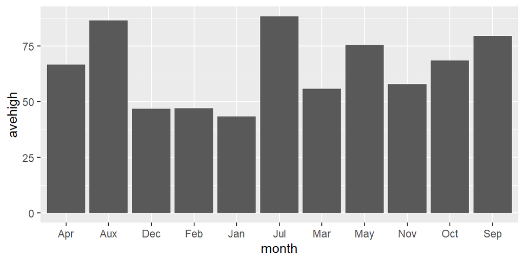

```r
    ggplot(dcclimate, aes(x = month, y = avehigh)) +
      geom_col()
```

- Factors help us with all of these issues.
- You have to be **very** careful about factors.

```r
    x  <- c("51", "32", "15", "2", "32")
    xf <- factor(x)
    xf
```

```
## [1] 51 32 15 2  32
## Levels: 15 2 32 51
```

```r
    as.numeric(x)
```

```
## [1] 51 32 15  2 32
```

```r
    class(as.numeric(xf))
```

```
## [1] "numeric"
```

```r
    as.numeric("Hello")
```

```
## [1] NA
```

```r
    as.numeric(factor("Hello"))
```

```
## [1] 1
```

```r
    fac1 <- factor(c("x1", "x2", "x3"))
    fac2 <- factor(c("y1", "y2", "y3"))
    c(fac1, fac2)
```

```
## [1] x1 x2 x3 y1 y2 y3
## Levels: x1 x2 x3 y1 y2 y3
```

- If you are 100% sure that all levels are numerics and are incorrectly specified as factors, then do the following to convert to numeric:

```r
xf
```

```
## [1] 51 32 15 2  32
## Levels: 15 2 32 51
```

```r
    parse_number(levels(xf)[xf]) ->
  nb
nb
```

```
## [1] 51 32 15  2 32
```

```r
class(nb)
```

```
## [1] "numeric"
```

## 11.6 Creating Factors

- Use `factor()` or `parse_factor()` to create a factor variable
- `parse_factor()` returns better warnings, so I would recommend always using that.

```r
    monthvec <- c("Jan", "Feb", "Mar", "Apr", "May", "Jun",
                  "Jul", "Aug", "Sep", "Oct", "Nov", "Dec")
    dcclimate %>%
      mutate(monthfc = factor(month, levels = monthvec)) ->
      dcclimate

    dcclimate %>%
      mutate(monthfc2 = parse_factor(month, levels = monthvec)) ->
      dcclimate
```

```
## Warning: There was 1 warning in `mutate()`.
## ℹ In argument: `monthfc2 = parse_factor(month, levels = monthvec)`.
## Caused by warning:
## ! 1 parsing failure.
## row col           expected actual
##   7  -- value in level set    Aux
```

```r
    dcclimate$monthfc
```

```
##  [1] Jan  Feb  Mar  Apr  May  Jul  <NA> Sep  Oct  Nov  Dec
## Levels: Jan Feb Mar Apr May Jun Jul Aug Sep Oct Nov Dec
```

- If you do not specify the `levels` argument, R will assume that the levels are the unique values of the vector.
  - `factor()` takes the order of the levels to be the same order returned by `sort()`.
  - `parse_factor()` takes the order of the levels to be the same order as the order of the value introduced.

```r
    x <- c("A", "string", "vector", "is", "a", "string", "vector")
    factor(x)
```

```
## [1] A      string vector is     a      string vector
## Levels: a A is string vector
```

```r
    sort(unique(x))
```

```
## [1] "a"      "A"      "is"     "string" "vector"
```

```r
    parse_factor(x)
```

```
## [1] A      string vector is     a      string vector
## Levels: A string vector is a
```

- You can always see the levels of a factor (and their order) using the `levels()` function

```r
    levels(dcclimate$monthfc)
```

```
##  [1] "Jan" "Feb" "Mar" "Apr" "May" "Jun" "Jul" "Aug" "Sep" "Oct" "Nov" "Dec"
```

- Other options are the `fct_unique()` and `fct_count()` functions from the forcats package.

```r
    fct_unique(dcclimate$monthfc)
```

```
##  [1] Jan  Feb  Mar  Apr  May  Jun  Jul  Aug  Sep  Oct  Nov  Dec  <NA>
## Levels: Jan Feb Mar Apr May Jun Jul Aug Sep Oct Nov Dec
```

```r
    fct_count(dcclimate$monthfc)
```

```
## # A tibble: 13 × 2
##    f         n
##    <fct> <int>
##  1 Jan       1
##  2 Feb       1
##  3 Mar       1
##  4 Apr       1
##  5 May       1
##  6 Jun       0
##  7 Jul       1
##  8 Aug       0
##  9 Sep       1
## 10 Oct       1
## 11 Nov       1
## 12 Dec       1
## 13 <NA>      1
```

- You can count the number of levels with `nlevels()`.

```r
    nlevels(dcclimate$monthfc)
```

```
## [1] 12
```

- Once we have a factor variable, the order of the aesthetic map is set in ggplot.

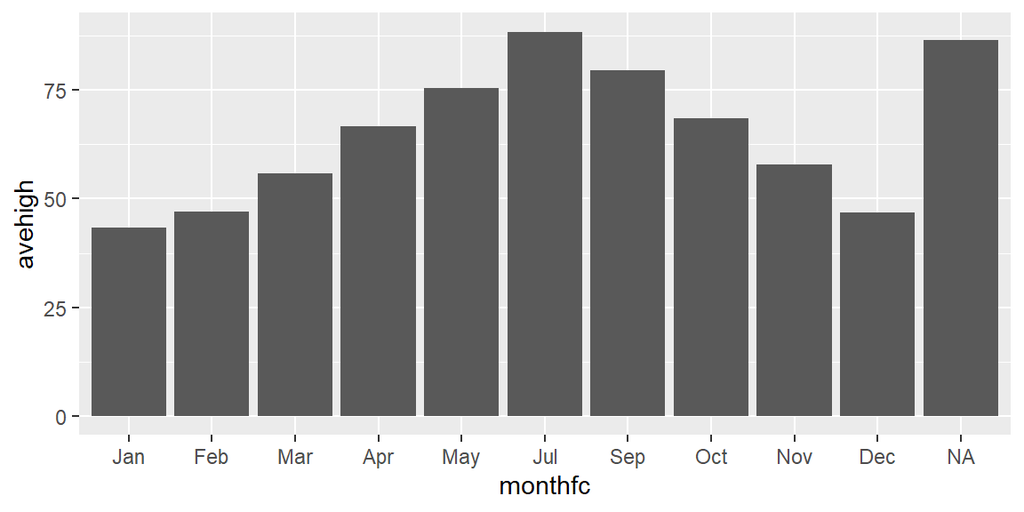

```r
    ggplot(dcclimate, aes(x = monthfc, y = avehigh)) +
      geom_col()
```

- We can include missing levels by using the `drop = FALSE` argument in the appropriate scale call:

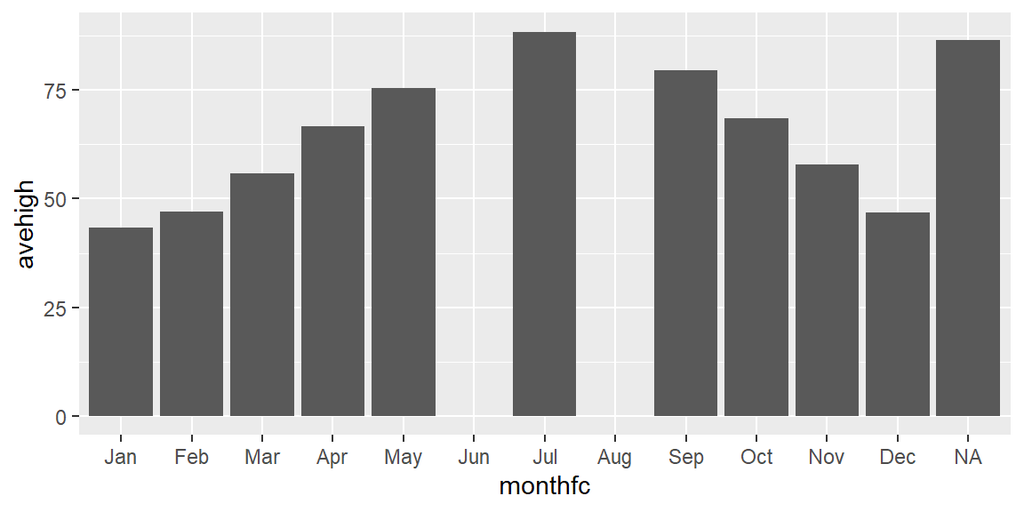

```r
    ggplot(dcclimate, aes(x = monthfc, y = avehigh)) +
      geom_col() +
      scale_x_discrete(drop = FALSE)
```

## 11.7 forcats

- forcats is an R package which makes two things much easier in R:
  - Changing the order of the levels of the factor variable.
  - Changing the levels of the factor variable.
- It also a few other helper functions for factors.
- All forcat functions begin with `fct_`. So you can type “fct_” then use tab-completion to scroll through the possible functions.
- forcats is a part of the tidyverse, so you don’t need to load it separately when you load the tidyverse.

### 11.7.1 Changing the Order of the Levels

- Consider the subset of the [General Social Survey](https://en.wikipedia.org/wiki/General_Social_Survey) stored in the `gss_cat` data in forcats.

```r
    data(gss_cat)
    glimpse(gss_cat)
```

```
## Rows: 21,483
## Columns: 9
## $ year    <int> 2000, 2000, 2000, 2000, 2000, 2000, 2000, 2000, 2000, 2000, 20…
## $ marital <fct> Never married, Divorced, Widowed, Never married, Divorced, Mar…
## $ age     <int> 26, 48, 67, 39, 25, 25, 36, 44, 44, 47, 53, 52, 52, 51, 52, 40…
## $ race    <fct> White, White, White, White, White, White, White, White, White,…
## $ rincome <fct> $8000 to 9999, $8000 to 9999, Not applicable, Not applicable, …
## $ partyid <fct> "Ind,near rep", "Not str republican", "Independent", "Ind,near…
## $ relig   <fct> Protestant, Protestant, Protestant, Orthodox-christian, None, …
## $ denom   <fct> "Southern baptist", "Baptist-dk which", "No denomination", "No…
## $ tvhours <int> 12, NA, 2, 4, 1, NA, 3, NA, 0, 3, 2, NA, 1, NA, 1, 7, NA, 3, 3…
```

- You often want to change the order of the levels of a factor to make plots more insightful.

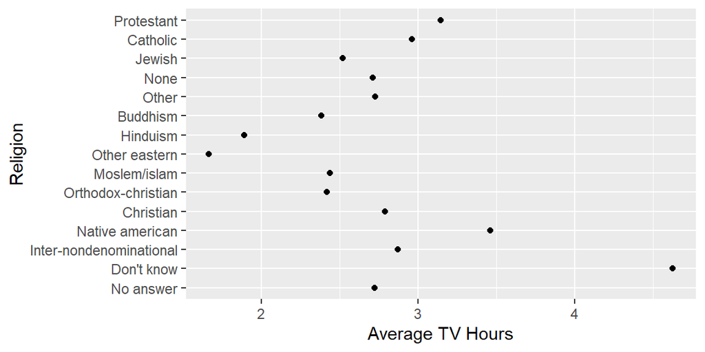

```r
    gss_cat %>%
      group_by(relig) %>%
      summarize(tvhours_mean = mean(tvhours, na.rm = TRUE)) ->
      tvdat

    ggplot(tvdat, aes(x = tvhours_mean, y = relig)) +
      geom_point() +
      xlab("Average TV Hours") +
      ylab("Religion")
```

- `fct_reorder()` reorders the levels of a factor according to some values of another variable. The arguments are:
  - `f`: The factor vector.
  - `x`: A numeric vector used to reorder the levels.
  - `fun`: A function applied to `x`, the result of which will be used to order the levels of `f`.

```r
    levels(tvdat$relig)
```

```
##  [1] "No answer"               "Don't know"
##  [3] "Inter-nondenominational" "Native american"
##  [5] "Christian"               "Orthodox-christian"
##  [7] "Moslem/islam"            "Other eastern"
##  [9] "Hinduism"                "Buddhism"
## [11] "Other"                   "None"
## [13] "Jewish"                  "Catholic"
## [15] "Protestant"              "Not applicable"
```

```r
    tvdat %>%
      mutate(relig = fct_reorder(relig, tvhours_mean)) ->
      tvdat
    levels(tvdat$relig)
```

```
##  [1] "Other eastern"           "Hinduism"
##  [3] "Buddhism"                "Orthodox-christian"
##  [5] "Moslem/islam"            "Jewish"
##  [7] "None"                    "No answer"
##  [9] "Other"                   "Christian"
## [11] "Inter-nondenominational" "Catholic"
## [13] "Protestant"              "Native american"
## [15] "Don't know"              "Not applicable"
```

- The plot now reorders the y-axis according to the new level order.

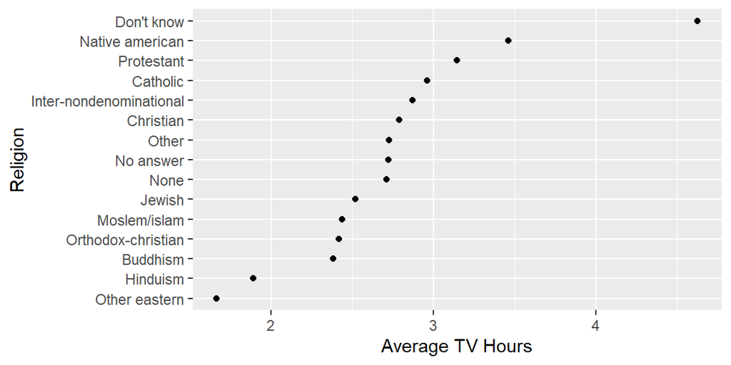

```r
    ggplot(tvdat, aes(x = tvhours_mean, y = relig)) +
      geom_point() +
      xlab("Average TV Hours") +
      ylab("Religion")
```

- `fct_rev()` reverses the order of the factors.

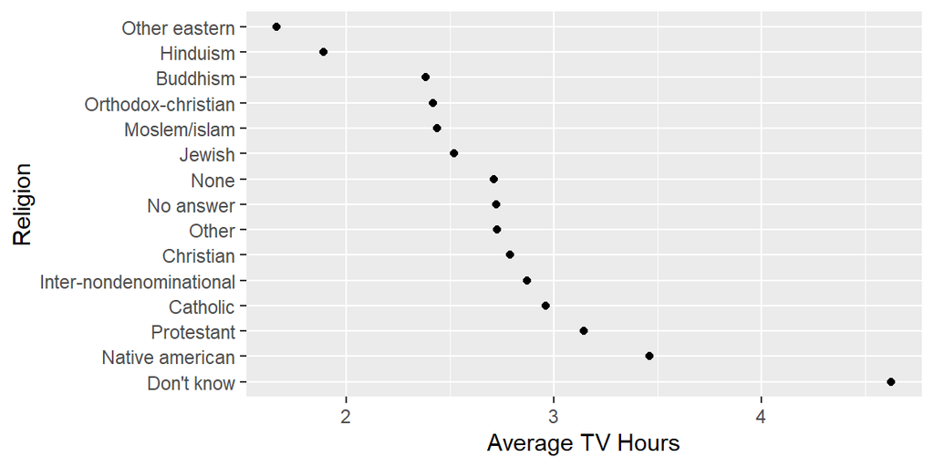

```r
    tvdat %>%
      mutate(relig = fct_rev(relig)) %>%
      ggplot(aes(x = tvhours_mean, y = relig)) +
        geom_point() +
        xlab("Average TV Hours") +
        ylab("Religion")
```

- `fct_relevel()` allows you to move existing levels to any location.

```r
    ## Moves "None" to first level
    fct_relevel(tvdat$relig, "None") %>%
      levels()
```

```
##  [1] "None"                    "Other eastern"
##  [3] "Hinduism"                "Buddhism"
##  [5] "Orthodox-christian"      "Moslem/islam"
##  [7] "Jewish"                  "No answer"
##  [9] "Other"                   "Christian"
## [11] "Inter-nondenominational" "Catholic"
## [13] "Protestant"              "Native american"
## [15] "Don't know"              "Not applicable"
```

```r
    ## Moves "None" to the third level
    fct_relevel(tvdat$relig, "None", after = 2L) %>%
      levels()
```

```
##  [1] "Other eastern"           "Hinduism"
##  [3] "None"                    "Buddhism"
##  [5] "Orthodox-christian"      "Moslem/islam"
##  [7] "Jewish"                  "No answer"
##  [9] "Other"                   "Christian"
## [11] "Inter-nondenominational" "Catholic"
## [13] "Protestant"              "Native american"
## [15] "Don't know"              "Not applicable"
```

```r
    ## Moves "None" to the last level
    fct_relevel(tvdat$relig, "None", after = nlevels(tvdat$relig)) %>%
      levels()
```

```
##  [1] "Other eastern"           "Hinduism"
##  [3] "Buddhism"                "Orthodox-christian"
##  [5] "Moslem/islam"            "Jewish"
##  [7] "No answer"               "Other"
##  [9] "Christian"               "Inter-nondenominational"
## [11] "Catholic"                "Protestant"
## [13] "Native american"         "Don't know"
## [15] "Not applicable"          "None"
```

```r
    ## Returns a warning because "Cthulhuism" is not a level
    fct_relevel(tvdat$relig, "Cthulhuism")
```

```
##  [1] No answer               Don't know              Inter-nondenominational
##  [4] Native american         Christian               Orthodox-christian
##  [7] Moslem/islam            Other eastern           Hinduism
## [10] Buddhism                Other                   None
## [13] Jewish                  Catholic                Protestant
## 16 Levels: Other eastern Hinduism Buddhism Orthodox-christian ... Not applicable
```

### 11.7.2 Modify Factor Levels

- Let’s look at the levels of `partyid` in `gss_cat`.

```r
    levels(gss_cat$partyid)
```

```
##  [1] "No answer"          "Don't know"         "Other party"
##  [4] "Strong republican"  "Not str republican" "Ind,near rep"
##  [7] "Independent"        "Ind,near dem"       "Not str democrat"
## [10] "Strong democrat"
```

- Use `fct_recode()` to change the levels.

```r
    gss_cat %>%
      mutate(partyid = fct_recode(partyid,
                                  "Republican, strong"    = "Strong republican",
                                  "Republican, weak"      = "Not str republican",
                                  "Independent, near rep" = "Ind,near rep",
                                  "Independent, near dem" = "Ind,near dem",
                                  "Democrat, weak"        = "Not str democrat",
                                  "Democrat, strong"      = "Strong democrat"
                                  )) ->
      gss_cat
    levels(gss_cat$partyid)
```

```
##  [1] "No answer"             "Don't know"            "Other party"
##  [4] "Republican, strong"    "Republican, weak"      "Independent, near rep"
##  [7] "Independent"           "Independent, near dem" "Democrat, weak"
## [10] "Democrat, strong"
```

- New level goes on the left of the equals sign. Old level goes on the right. (Just like `mutate()`!)
- **Exercise**: Modify the factor levels of `marital` to be abbreviations of their long-names. For example, “Divorced” can just be “D”

## 11.8 Other Useful Functions.

- `fct_c()`: is the safe way to combine factor vectors.

```r
    fc1 <- parse_factor(c("A", "B"))
    fc1
```

```
## [1] A B
## Levels: A B
```

```r
    fc2 <- parse_factor(c("C", "D"))
    fc2
```

```
## [1] C D
## Levels: C D
```

```r
    fct_c(fc1, fc2)
```

```
## [1] A B C D
## Levels: A B C D
```

- `fct_collapse()`: combine multiple levels into one level.

```r
    fc <- parse_factor(c("A", "B", "C", "A", "B", "C"))
    fc
```

```
## [1] A B C A B C
## Levels: A B C
```

```r
    fct_collapse(fc, "blah" = c("A", "B"))
```

```
## [1] blah blah C    blah blah C
## Levels: blah C
```

- `fct_drop()`: removes any levels that are unused.

```r
    fc <- parse_factor(c("A", "B"), levels = c("A", "B", "C"))
    fc
```

```
## [1] A B
## Levels: A B C
```

```r
    fct_drop(fc)
```

```
## [1] A B
## Levels: A B
```

- `fct_expand()`: adds a new level.

```r
    fc <- parse_factor(c("A", "B"))
    fc
```

```
## [1] A B
## Levels: A B
```

```r
    fct_expand(fc, "C")
```

```
## [1] A B
## Levels: A B C
```

- `fct_infreq()`: Order by frequency of a level.

```r
    fc <- parse_factor(c("A", "B", "C", "B", "C", "C"))
    fct_count(fc)
```

```
## # A tibble: 3 × 2
##   f         n
##   <fct> <int>
## 1 A         1
## 2 B         2
## 3 C         3
```

```r
    fct_infreq(fc) %>%
      fct_count()
```

```
## # A tibble: 3 × 2
##   f         n
##   <fct> <int>
## 1 C         3
## 2 B         2
## 3 A         1
```